# Lab1

## Лабораторная работа № 1

### Андрюшина Мария, 932001

### Задание №1

### Бинарный классификатор

```python
import pandas as pd
import matplotlib.pyplot as plt
import numpy as np
from sklearn.model_selection import train_test_split
from sklearn.metrics import recall_score, precision_score, balanced_accuracy_score, roc_auc_score, roc_curve
from sklearn.metrics import mean_squared_error, mean_absolute_error, r2_score
from sklearn.metrics import RocCurveDisplay
from sklearn.preprocessing import MinMaxScaler
from keras.models import Sequential
from keras import layers
from keras.layers import Dense
from keras.callbacks import ModelCheckpoint, EarlyStopping
from tensorflow.keras.utils import to_categorical
```

### Работа с данными

```python
df = pd.read_csv('diabetes_012_health_indicators_BRFSS2015.csv')
df.head()
```

|  | Diabetes_012 | HighBP | HighChol | CholCheck | BMI | Smoker | Stroke | HeartDiseaseorAttack | PhysActivity | Fruits | ... | AnyHealthcare | NoDocbcCost | GenHlth | MentHlth | PhysHlth | DiffWalk | Sex | Age | Education | Income |
| --- | --- | --- | --- | --- | --- | --- | --- | --- | --- | --- | --- | --- | --- | --- | --- | --- | --- | --- | --- | --- | --- |
| 0 | 0.0 | 1.0 | 1.0 | 1.0 | 40.0 | 1.0 | 0.0 | 0.0 | 0.0 | 0.0 | ... | 1.0 | 0.0 | 5.0 | 18.0 | 15.0 | 1.0 | 0.0 | 9.0 | 4.0 | 3.0 |
| 1 | 0.0 | 0.0 | 0.0 | 0.0 | 25.0 | 1.0 | 0.0 | 0.0 | 1.0 | 0.0 | ... | 0.0 | 1.0 | 3.0 | 0.0 | 0.0 | 0.0 | 0.0 | 7.0 | 6.0 | 1.0 |
| 2 | 0.0 | 1.0 | 1.0 | 1.0 | 28.0 | 0.0 | 0.0 | 0.0 | 0.0 | 1.0 | ... | 1.0 | 1.0 | 5.0 | 30.0 | 30.0 | 1.0 | 0.0 | 9.0 | 4.0 | 8.0 |
| 3 | 0.0 | 1.0 | 0.0 | 1.0 | 27.0 | 0.0 | 0.0 | 0.0 | 1.0 | 1.0 | ... | 1.0 | 0.0 | 2.0 | 0.0 | 0.0 | 0.0 | 0.0 | 11.0 | 3.0 | 6.0 |
| 4 | 0.0 | 1.0 | 1.0 | 1.0 | 24.0 | 0.0 | 0.0 | 0.0 | 1.0 | 1.0 | ... | 1.0 | 0.0 | 2.0 | 3.0 | 0.0 | 0.0 | 0.0 | 11.0 | 5.0 | 4.0 |

5 rows × 22 columns

```python
df.shape
```

```
(253680, 22)
```

```python
#Пропусков нет
df.isnull().sum()/df.shape[0]
```

```
Diabetes_012            0.0
HighBP                  0.0
HighChol                0.0
CholCheck               0.0
BMI                     0.0
Smoker                  0.0
Stroke                  0.0
HeartDiseaseorAttack    0.0
PhysActivity            0.0
Fruits                  0.0
Veggies                 0.0
HvyAlcoholConsump       0.0
AnyHealthcare           0.0
NoDocbcCost             0.0
GenHlth                 0.0
MentHlth                0.0
PhysHlth                0.0
DiffWalk                0.0
Sex                     0.0
Age                     0.0
Education               0.0
Income                  0.0
dtype: float64
```

```python
df.info()
```

```
<class 'pandas.core.frame.DataFrame'>
RangeIndex: 253680 entries, 0 to 253679
Data columns (total 22 columns):
 #   Column                Non-Null Count   Dtype
---  ------                --------------   -----
 0   Diabetes_012          253680 non-null  float64
 1   HighBP                253680 non-null  float64
 2   HighChol              253680 non-null  float64
 3   CholCheck             253680 non-null  float64
 4   BMI                   253680 non-null  float64
 5   Smoker                253680 non-null  float64
 6   Stroke                253680 non-null  float64
 7   HeartDiseaseorAttack  253680 non-null  float64
 8   PhysActivity          253680 non-null  float64
 9   Fruits                253680 non-null  float64
 10  Veggies               253680 non-null  float64
 11  HvyAlcoholConsump     253680 non-null  float64
 12  AnyHealthcare         253680 non-null  float64
 13  NoDocbcCost           253680 non-null  float64
 14  GenHlth               253680 non-null  float64
 15  MentHlth              253680 non-null  float64
 16  PhysHlth              253680 non-null  float64
 17  DiffWalk              253680 non-null  float64
 18  Sex                   253680 non-null  float64
 19  Age                   253680 non-null  float64
 20  Education             253680 non-null  float64
 21  Income                253680 non-null  float64
dtypes: float64(22)
memory usage: 42.6 MB
```

```python
df['Diabetes_012'] = df['Diabetes_012'].replace({2 : 1})
```

```python
df1 = df.drop_duplicates()
```

```python
df1.shape
```

```
(229712, 22)
```

### Создание моделей

#### Base Model

Разделим датасет на три части: тренировочную (70%), тестовую (20%) и валидационную (10%).

```python
X_train, X_rem, y_train, y_rem = train_test_split(df1.drop(['Diabetes_012'], axis=1), df1['Diabetes_012'],
                                                   train_size=0.7, random_state=77)

X_valid, X_test, y_valid, y_test = train_test_split(X_rem, y_rem, test_size=0.66, random_state=77)
```

Создадим базовую модель нейронной сети, состоящую из 2 слоёв:

1. 4 нейрона, функция активации - ReLU
2. 1 нейрон, функция активации - Sigmoid

```python
binary_classifier = Sequential(
    [
        layers.Dense(4, activation = 'relu', input_dim = X_train.shape[1]),
        layers.Dense(1, activation = 'sigmoid')
    ]
)
binary_classifier.summary()
```

```
Model: "sequential"
_________________________________________________________________
 Layer (type)                Output Shape              Param #
=================================================================
 dense (Dense)               (None, 4)                 88

 dense_1 (Dense)             (None, 1)                 5

=================================================================
Total params: 93 (372.00 Byte)
Trainable params: 93 (372.00 Byte)
Non-trainable params: 0 (0.00 Byte)
_________________________________________________________________
```

```python
binary_classifier.compile(loss = 'binary_crossentropy', optimizer = 'adam', metrics = 'accuracy')
```

```python
early_stop = EarlyStopping(monitor = 'val_accuracy', patience = 10, mode = 'max', verbose =1)
checkpoint = ModelCheckpoint('cancer_weights-{epoch:02d}-{val_accuracy:.3f}.hdf5',
                             monitor = 'val_accuracy', verbose = 1, mode = 'max',
                             save_best_only = True)
callbacks_list = [early_stop,checkpoint]
```

Зададим количество объектов в одном батче, равное 10, и число эпох, равное 100:

```python
binary_class_history = binary_classifier.fit(X_train, y_train, batch_size = 10, validation_data = (X_valid, y_valid),
                                        callbacks = callbacks_list, epochs = 100)
```

```
Epoch 1: val_accuracy improved from -inf to 0.83231, saving model to cancer_weights-01-0.832.hdf5
```

```
Epoch 2: val_accuracy did not improve from 0.83231
Epoch 3: val_accuracy improved from 0.83231 to 0.83423, saving model to cancer_weights-03-0.834.hdf5
Epoch 4: val_accuracy improved from 0.83423 to 0.83470, saving model to cancer_weights-04-0.835.hdf5
Epoch 5: val_accuracy improved from 0.83470 to 0.83500, saving model to cancer_weights-05-0.835.hdf5
Epoch 6: val_accuracy improved from 0.83500 to 0.83577, saving model to cancer_weights-06-0.836.hdf5
Epoch 7: val_accuracy improved from 0.83577 to 0.83581, saving model to cancer_weights-07-0.836.hdf5
Epoch 8: val_accuracy did not improve from 0.83581
Epoch 9: val_accuracy did not improve from 0.83581
Epoch 10: val_accuracy did not improve from 0.83581
Epoch 11: val_accuracy did not improve from 0.83581
Epoch 12: val_accuracy did not improve from 0.83581
Epoch 13: val_accuracy did not improve from 0.83581
Epoch 14: val_accuracy did not improve from 0.83581
Epoch 15: val_accuracy did not improve from 0.83581
Epoch 16: val_accuracy did not improve from 0.83581
Epoch 17: val_accuracy did not improve from 0.83581
Epoch 17: early stopping
```

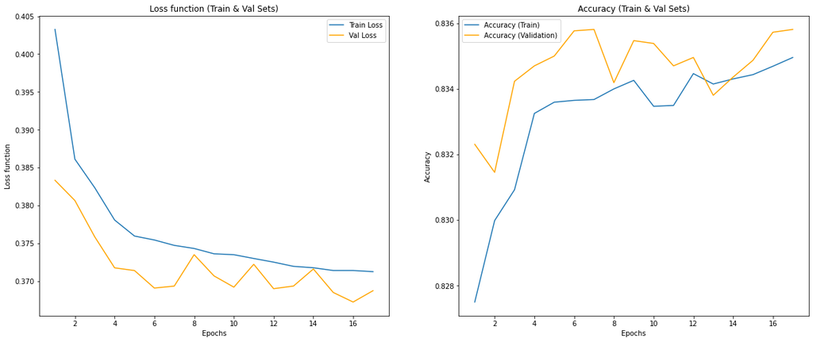

```python
plt.figure(figsize=(20,8))
loss_function = binary_class_history.history['loss']
val_loss_function = binary_class_history.history['val_loss']
epochs = range(1,len(loss_function)+1)

acc = binary_class_history.history['accuracy']
val_acc = binary_class_history.history['val_accuracy']
epochs = range(1,len(acc)+1)

plt.subplot(1, 2, 1)
plt.title('Loss function (Train & Val Sets)')
plt.plot(epochs,loss_function,label='Train Loss')
plt.plot(epochs,val_loss_function,color='orange',label='Val Loss')
plt.xlabel('Epochs')
plt.ylabel('Loss function')
plt.legend()

plt.subplot(1, 2, 2)
plt.title('Accuracy (Train & Val Sets)')
plt.plot(epochs,acc,label='Accuracy (Train)')
plt.plot(epochs,val_acc,color='orange',label='Accuracy (Validation)')
plt.xlabel('Epochs')
plt.ylabel('Accuracy')
plt.legend()
```

```python
probs = binary_classifier.predict(X_test)[:,0]
truth = y_test
```

```python
preds = (probs>0.5).astype(int)
preds
```

```
array([0, 0, 0, ..., 0, 0, 1])
```

```python
df_metrics = pd.DataFrame(columns=['model', 'recall', 'precision', 'weighted_accuracy', 'auc'])
recall = round(recall_score(truth, preds), 4)
precision = round(precision_score(truth, preds), 4)
weighted_accuracy = round(balanced_accuracy_score(truth, preds), 4)
auc = round(roc_auc_score(truth, probs), 4)
df_metrics.loc[len(df_metrics.index)] = ['base_model', recall, precision, weighted_accuracy, auc]
```

```python
df_metrics
```

|  | model | recall | precision | weighted_accuracy | auc |
| --- | --- | --- | --- | --- | --- |
| 0 | base_model | 0.1277 | 0.611 | 0.5556 | 0.8023 |

#### Second Model

Во второй модели увеличим количество слоёв, не увиличивая число нейронов и чередуя функции активации:

1. 4 нейрона, функция активации - ReLU
2. 4 нейрона, функция активации - Sigmoid
3. 4 нейрона, функция активации - ReLU
4. 4 нейрона, функция активации - Sigmoid
5. 2 нейрона, функция активации - ReLU
6. 1 нейрон, функция активации - Sigmoid

```python
binary_classifier_2 = Sequential(
    [
        layers.Dense(4, activation = 'relu', input_dim = X_train.shape[1]),
        layers.Dense(4, activation = 'sigmoid'),
        layers.Dense(4, activation = 'relu'),
        layers.Dense(4, activation = 'sigmoid'),
        layers.Dense(2, activation = 'relu'),
        layers.Dense(1, activation = 'sigmoid')
    ]
)
binary_classifier_2.summary()
```

```
Model: "sequential_2"
_________________________________________________________________
 Layer (type)                Output Shape              Param #
=================================================================
 dense_8 (Dense)             (None, 4)                 88

 dense_9 (Dense)             (None, 4)                 20

 dense_10 (Dense)            (None, 4)                 20

 dense_11 (Dense)            (None, 4)                 20

 dense_12 (Dense)            (None, 2)                 10

 dense_13 (Dense)            (None, 1)                 3

=================================================================
Total params: 161 (644.00 Byte)
Trainable params: 161 (644.00 Byte)
Non-trainable params: 0 (0.00 Byte)
_________________________________________________________________
```

```python
binary_classifier_2.compile(loss = 'binary_crossentropy', optimizer = 'adam', metrics = 'accuracy')
```

```python
early_stop = EarlyStopping(monitor = 'val_accuracy', patience = 10, mode = 'max', verbose =1)
checkpoint = ModelCheckpoint('cancer2_weights-{epoch:02d}-{val_accuracy:.3f}.hdf5',
                             monitor = 'val_accuracy', verbose = 1, mode = 'max',
                             save_best_only = True)
callbacks_list = [early_stop,checkpoint]
```

```python
binary_class_history = binary_classifier_2.fit(X_train, y_train, batch_size = 10, validation_data = (X_valid, y_valid),
                                        callbacks = callbacks_list, epochs = 100)
```

```
Epoch 1: val_accuracy improved from -inf to 0.82949, saving model to cancer2_weights-01-0.829.hdf5
```

```
Epoch 2: val_accuracy improved from 0.82949 to 0.83589, saving model to cancer2_weights-02-0.836.hdf5
Epoch 3: val_accuracy improved from 0.83589 to 0.83636, saving model to cancer2_weights-03-0.836.hdf5
Epoch 4: val_accuracy did not improve from 0.83636
Epoch 5: val_accuracy improved from 0.83636 to 0.83649, saving model to cancer2_weights-05-0.836.hdf5
Epoch 6: val_accuracy did not improve from 0.83649
Epoch 7: val_accuracy did not improve from 0.83649
Epoch 8: val_accuracy did not improve from 0.83649
Epoch 9: val_accuracy did not improve from 0.83649
Epoch 10: val_accuracy did not improve from 0.83649
Epoch 11: val_accuracy did not improve from 0.83649
Epoch 12: val_accuracy did not improve from 0.83649
Epoch 13: val_accuracy did not improve from 0.83649
Epoch 14: val_accuracy did not improve from 0.83649
Epoch 15: val_accuracy did not improve from 0.83649
Epoch 15: early stopping
```

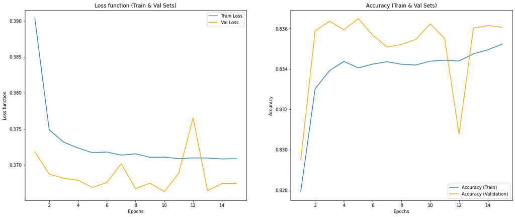

```python
plt.figure(figsize=(20,8))
loss_function = binary_class_history.history['loss']
val_loss_function = binary_class_history.history['val_loss']
epochs = range(1,len(loss_function)+1)

acc = binary_class_history.history['accuracy']
val_acc = binary_class_history.history['val_accuracy']
epochs = range(1,len(acc)+1)

plt.subplot(1, 2, 1)
plt.title('Loss function (Train & Val Sets)')
plt.plot(epochs,loss_function,label='Train Loss')
plt.plot(epochs,val_loss_function,color='orange',label='Val Loss')
plt.xlabel('Epochs')
plt.ylabel('Loss function')
plt.legend()

plt.subplot(1, 2, 2)
plt.title('Accuracy (Train & Val Sets)')
plt.plot(epochs,acc,label='Accuracy (Train)')
plt.plot(epochs,val_acc,color='orange',label='Accuracy (Validation)')
plt.xlabel('Epochs')
plt.ylabel('Accuracy')
plt.legend()
```

```python
probs = binary_classifier_2.predict(X_test)[:,0]
truth = y_test
```

```python
preds = (probs>0.5).astype(int)
preds
```

```
array([0, 0, 0, ..., 0, 0, 1])
```

```python
recall = round(recall_score(truth, preds), 4)
precision = round(precision_score(truth, preds), 4)
weighted_accuracy = round(balanced_accuracy_score(truth, preds), 4)
auc = round(roc_auc_score(truth, probs), 4)
df_metrics.loc[len(df_metrics.index)] = ['seсond_model', recall, precision, weighted_accuracy, auc]
```

```python
df_metrics
```

|  | model | recall | precision | weighted_accuracy | auc |
| --- | --- | --- | --- | --- | --- |
| 0 | base_model | 0.1277 | 0.6110 | 0.5556 | 0.8023 |
| 1 | seсond_model | 0.1958 | 0.5608 | 0.5823 | 0.8032 |

#### Third Model

Увеличим количество нейронов на каждом слое, кроме последнего:

1. 64 нейрона, функция активации - ReLU
2. 64 нейрона, функция активации - Sigmoid
3. 32 нейрона, функция активации - ReLU
4. 16 нейронов, функция активации - Sigmoid
5. 8 нейронов, функция активации - ReLU
6. 1 нейрон, функция активации - Sigmoid

```python
binary_classifier_3 = Sequential(
    [
        layers.Dense(64, activation = 'relu', input_dim = X_train.shape[1]),
        layers.Dense(64, activation = 'sigmoid'),
        layers.Dense(32, activation = 'relu'),
        layers.Dense(16, activation = 'sigmoid'),
        layers.Dense(8, activation = 'relu'),
        layers.Dense(1, activation = 'sigmoid')
    ]
)
binary_classifier_3.summary()
```

```
Model: "sequential_3"
_________________________________________________________________
 Layer (type)                Output Shape              Param #
=================================================================
 dense_14 (Dense)            (None, 64)                1408

 dense_15 (Dense)            (None, 64)                4160

 dense_16 (Dense)            (None, 32)                2080

 dense_17 (Dense)            (None, 16)                528

 dense_18 (Dense)            (None, 8)                 136

 dense_19 (Dense)            (None, 1)                 9

=================================================================
Total params: 8321 (32.50 KB)
Trainable params: 8321 (32.50 KB)
Non-trainable params: 0 (0.00 Byte)
_________________________________________________________________
```

```python
binary_classifier_3.compile(loss = 'binary_crossentropy', optimizer = 'adam', metrics = 'accuracy')
```

```python
early_stop = EarlyStopping(monitor = 'val_accuracy', patience = 10, mode = 'max', verbose =1)
checkpoint = ModelCheckpoint('cancer3_weights-{epoch:02d}-{val_accuracy:.3f}.hdf5',
                             monitor = 'val_accuracy', verbose = 1, mode = 'max',
                             save_best_only = True)
callbacks_list = [early_stop,checkpoint]
```

Увеличим число объектов в одном батче в 10 раз и уменьшим количество эпох в 2 раза:

```python
binary_class_history = binary_classifier_3.fit(X_train, y_train, batch_size = 100, validation_data = (X_valid, y_valid),
                                        callbacks = callbacks_list, epochs = 50)
```

```
Epoch 1: val_accuracy improved from -inf to 0.83606, saving model to cancer3_weights-01-0.836.hdf5
```

```
Epoch 2: val_accuracy improved from 0.83606 to 0.83641, saving model to cancer3_weights-02-0.836.hdf5
Epoch 3: val_accuracy improved from 0.83641 to 0.83756, saving model to cancer3_weights-03-0.838.hdf5
Epoch 4: val_accuracy improved from 0.83756 to 0.83760, saving model to cancer3_weights-04-0.838.hdf5
Epoch 5: val_accuracy did not improve from 0.83760
Epoch 6: val_accuracy did not improve from 0.83760
Epoch 7: val_accuracy did not improve from 0.83760
Epoch 8: val_accuracy did not improve from 0.83760
Epoch 9: val_accuracy did not improve from 0.83760
Epoch 10: val_accuracy did not improve from 0.83760
Epoch 11: val_accuracy did not improve from 0.83760
Epoch 12: val_accuracy improved from 0.83760 to 0.83850, saving model to cancer3_weights-12-0.838.hdf5
Epoch 13: val_accuracy did not improve from 0.83850
Epoch 14: val_accuracy did not improve from 0.83850
Epoch 15: val_accuracy did not improve from 0.83850
Epoch 16: val_accuracy did not improve from 0.83850
Epoch 17: val_accuracy did not improve from 0.83850
Epoch 18: val_accuracy did not improve from 0.83850
Epoch 19: val_accuracy did not improve from 0.83850
Epoch 20: val_accuracy did not improve from 0.83850
Epoch 21: val_accuracy did not improve from 0.83850
Epoch 22: val_accuracy did not improve from 0.83850
Epoch 22: early stopping
```

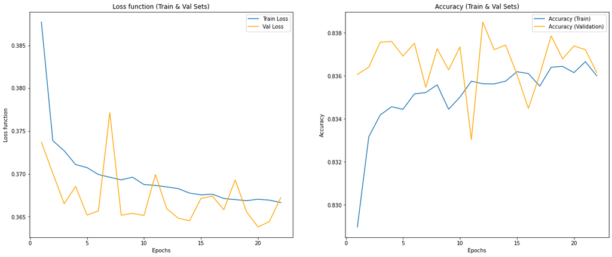

```python
plt.figure(figsize=(20,8))
loss_function = binary_class_history.history['loss']
val_loss_function = binary_class_history.history['val_loss']
epochs = range(1,len(loss_function)+1)

acc = binary_class_history.history['accuracy']
val_acc = binary_class_history.history['val_accuracy']
epochs = range(1,len(acc)+1)

plt.subplot(1, 2, 1)
plt.title('Loss function (Train & Val Sets)')
plt.plot(epochs,loss_function,label='Train Loss')
plt.plot(epochs,val_loss_function,color='orange',label='Val Loss')
plt.xlabel('Epochs')
plt.ylabel('Loss function')
plt.legend()

plt.subplot(1, 2, 2)
plt.title('Accuracy (Train & Val Sets)')
plt.plot(epochs,acc,label='Accuracy (Train)')
plt.plot(epochs,val_acc,color='orange',label='Accuracy (Validation)')
plt.xlabel('Epochs')
plt.ylabel('Accuracy')
plt.legend()
```

```python
probs = binary_classifier_3.predict(X_test)[:,0]
truth = y_test
```

```python
preds = (probs>0.5).astype(int)
preds
```

```
array([0, 0, 0, ..., 0, 0, 0])
```

```python
recall = round(recall_score(truth, preds), 4)
precision = round(precision_score(truth, preds), 4)
weighted_accuracy = round(balanced_accuracy_score(truth, preds), 4)
auc = round(roc_auc_score(truth, probs), 4)
df_metrics.loc[len(df_metrics.index)] = ['third_model', recall, precision, weighted_accuracy, auc]
```

```python
df_metrics
```

|  | model | recall | precision | weighted_accuracy | auc |
| --- | --- | --- | --- | --- | --- |
| 0 | base_model | 0.1277 | 0.6110 | 0.5556 | 0.8023 |
| 1 | seсond_model | 0.1958 | 0.5608 | 0.5823 | 0.8032 |
| 2 | third_model | 0.1830 | 0.5674 | 0.5774 | 0.8030 |

#### Fourth Model

Добавим Dropout(0.1) после нескольких первых слоёв:

```python
binary_classifier_4 = Sequential(
    [
        layers.Dense(64, activation = 'relu', input_dim = X_train.shape[1]),
        layers.Dropout(0.1),
        layers.Dense(64, activation = 'sigmoid'),
        layers.Dropout(0.1),
        layers.Dense(32, activation = 'relu'),
        layers.Dropout(0.1),
        layers.Dense(16, activation = 'sigmoid'),
        layers.Dense(8, activation = 'relu'),
        layers.Dense(1, activation = 'sigmoid')
    ]
)
binary_classifier_4.summary()
```

```
Model: "sequential_5"
_________________________________________________________________
 Layer (type)                Output Shape              Param #
=================================================================
 dense_26 (Dense)            (None, 64)                1408

 dropout_3 (Dropout)         (None, 64)                0

 dense_27 (Dense)            (None, 64)                4160

 dropout_4 (Dropout)         (None, 64)                0

 dense_28 (Dense)            (None, 32)                2080

 dropout_5 (Dropout)         (None, 32)                0

 dense_29 (Dense)            (None, 16)                528

 dense_30 (Dense)            (None, 8)                 136

 dense_31 (Dense)            (None, 1)                 9

=================================================================
Total params: 8321 (32.50 KB)
Trainable params: 8321 (32.50 KB)
Non-trainable params: 0 (0.00 Byte)
_________________________________________________________________
```

Изменим процедуру оптимизации на SGD:

```python
binary_classifier_4.compile(loss = 'binary_crossentropy', optimizer = 'sgd', metrics = 'accuracy')
```

```python
early_stop = EarlyStopping(monitor = 'val_accuracy', patience = 10, mode = 'max', verbose =1)
checkpoint = ModelCheckpoint('cancer4_weights-{epoch:02d}-{val_accuracy:.3f}.hdf5',
                             monitor = 'val_accuracy', verbose = 1, mode = 'max',
                             save_best_only = True)
callbacks_list = [early_stop,checkpoint]
```

```python
binary_class_history = binary_classifier_4.fit(X_train, y_train, batch_size = 100, validation_data = (X_valid, y_valid),
                                        callbacks = callbacks_list, epochs = 50)
```

[output not shown]

[output not shown]

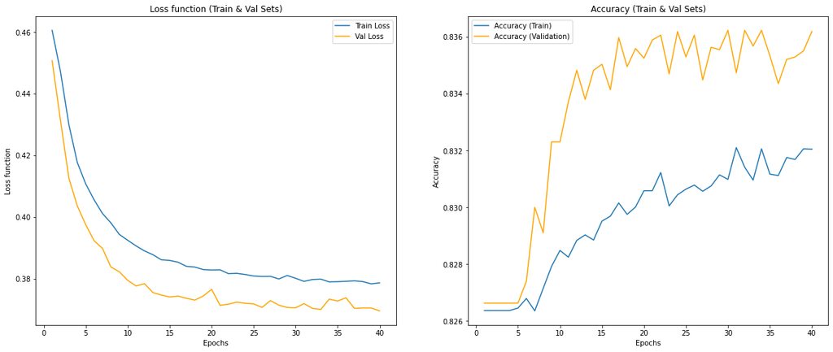

```python
plt.figure(figsize=(20,8))
loss_function = binary_class_history.history['loss']
val_loss_function = binary_class_history.history['val_loss']
epochs = range(1,len(loss_function)+1)

acc = binary_class_history.history['accuracy']
val_acc = binary_class_history.history['val_accuracy']
epochs = range(1,len(acc)+1)

plt.subplot(1, 2, 1)
plt.title('Loss function (Train & Val Sets)')
plt.plot(epochs,loss_function,label='Train Loss')
plt.plot(epochs,val_loss_function,color='orange',label='Val Loss')
plt.xlabel('Epochs')
plt.ylabel('Loss function')
plt.legend()

plt.subplot(1, 2, 2)
plt.title('Accuracy (Train & Val Sets)')
plt.plot(epochs,acc,label='Accuracy (Train)')
plt.plot(epochs,val_acc,color='orange',label='Accuracy (Validation)')
plt.xlabel('Epochs')
plt.ylabel('Accuracy')
plt.legend()
```

```python
probs = binary_classifier_4.predict(X_test)[:,0]
truth = y_test
```

```python
preds = (probs>0.5).astype(int)
preds
```

```
array([0, 0, 0, ..., 0, 0, 1])
```

```python
recall = round(recall_score(truth, preds), 4)
precision = round(precision_score(truth, preds), 4)
weighted_accuracy = round(balanced_accuracy_score(truth, preds), 4)
auc = round(roc_auc_score(truth, probs), 4)
df_metrics.loc[len(df_metrics.index)] = ['fourth_model', recall, precision, weighted_accuracy, auc]
```

```python
df_metrics
```

|  | model | recall | precision | weighted_accuracy | auc |
| --- | --- | --- | --- | --- | --- |
| 0 | base_model | 0.1277 | 0.6110 | 0.5556 | 0.8023 |
| 1 | seсond_model | 0.1958 | 0.5608 | 0.5823 | 0.8032 |
| 2 | third_model | 0.1830 | 0.5674 | 0.5774 | 0.8030 |
| 3 | fourth_model | 0.1476 | 0.5904 | 0.5634 | 0.7990 |

Анализируя полученные метрики 4-х моделей, можно сделать вывод, что наилучшим бинарным классификатором является Second Model.

Построим ROC-кривую для данной модели:

```python
probs_2 = binary_classifier_2.predict(X_test)[:,0]
truth = y_test
```

```python
preds_2 = (probs_2>0.5).astype(int)
preds_2
```

```
array([0, 0, 0, ..., 0, 0, 1])
```

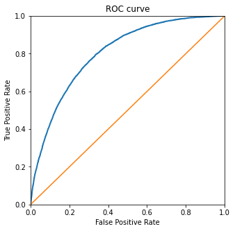

```python
fpr, tpr, thresholds = roc_curve(truth, probs_2, pos_label=1)
lw = 2
plt.rcParams['figure.figsize']=(5,5)
plt.plot(fpr, tpr, lw=lw, label='ROC curve ')
plt.plot([0, 1], [0, 1])
plt.xlim([0.0, 1.0])
plt.ylim([0.0, 1.0])
plt.xlabel('False Positive Rate')
plt.ylabel('True Positive Rate')
plt.title('ROC curve')

plt.show()
```

### Вывод

Среди четырёх моделей бинарных классификаторов лучше всего сработала Second Model. В ней увеличено число слоёв по сравнению с Base Model, но не увеличено число нейронов на каждом слое.

Оценка качества бинарных классификаторов происходила по следующим метрикам: Recall, Precision, Weighted Accuracy и AUC. Эти показатели у Second Model в среднем выше, чем у остальных моделей.

### Задание №2

### Многоклассовый классификатор

### Работа с данными

```python
df = pd.read_csv('bodyPerformance.csv')
df.head()
```

|  | age | gender | height_cm | weight_kg | body fat_% | diastolic | systolic | gripForce | sit and bend forward_cm | sit-ups counts | broad jump_cm | class |
| --- | --- | --- | --- | --- | --- | --- | --- | --- | --- | --- | --- | --- |
| 0 | 27.0 | M | 172.3 | 75.24 | 21.3 | 80.0 | 130.0 | 54.9 | 18.4 | 60.0 | 217.0 | C |
| 1 | 25.0 | M | 165.0 | 55.80 | 15.7 | 77.0 | 126.0 | 36.4 | 16.3 | 53.0 | 229.0 | A |
| 2 | 31.0 | M | 179.6 | 78.00 | 20.1 | 92.0 | 152.0 | 44.8 | 12.0 | 49.0 | 181.0 | C |
| 3 | 32.0 | M | 174.5 | 71.10 | 18.4 | 76.0 | 147.0 | 41.4 | 15.2 | 53.0 | 219.0 | B |
| 4 | 28.0 | M | 173.8 | 67.70 | 17.1 | 70.0 | 127.0 | 43.5 | 27.1 | 45.0 | 217.0 | B |

```python
df.shape
```

```
(13393, 12)
```

```python
#Пропусков нет
df.isnull().sum()/df.shape[0]
```

```
age                        0.0
gender                     0.0
height_cm                  0.0
weight_kg                  0.0
body fat_%                 0.0
diastolic                  0.0
systolic                   0.0
gripForce                  0.0
sit and bend forward_cm    0.0
sit-ups counts             0.0
broad jump_cm              0.0
class                      0.0
dtype: float64
```

```python
df.info()
```

```
<class 'pandas.core.frame.DataFrame'>
RangeIndex: 13393 entries, 0 to 13392
Data columns (total 12 columns):
 #   Column                   Non-Null Count  Dtype
---  ------                   --------------  -----
 0   age                      13393 non-null  float64
 1   gender                   13393 non-null  object
 2   height_cm                13393 non-null  float64
 3   weight_kg                13393 non-null  float64
 4   body fat_%               13393 non-null  float64
 5   diastolic                13393 non-null  float64
 6   systolic                 13393 non-null  float64
 7   gripForce                13393 non-null  float64
 8   sit and bend forward_cm  13393 non-null  float64
 9   sit-ups counts           13393 non-null  float64
 10  broad jump_cm            13393 non-null  float64
 11  class                    13393 non-null  object
dtypes: float64(10), object(2)
memory usage: 1.2+ MB
```

```python
print(df['gender'].unique())
print(df['class'].unique())
```

```
['M' 'F']
['C' 'A' 'B' 'D']
```

Закодируем значения в столбцах типа object:

```python
df['gender'] = df['gender'].replace({'M' : 1, 'F' : 0})
df = df.rename(columns={'gender' : 'is_male'})
df['class'] = df['class'].replace({'A' : 0, 'B' : 1, 'C' : 2, 'D' : 3})
```

```python
df1 = df.drop_duplicates()
```

```python
df1.shape
```

```
(13392, 12)
```

```python
df1.head()
```

|  | age | is_male | height_cm | weight_kg | body fat_% | diastolic | systolic | gripForce | sit and bend forward_cm | sit-ups counts | broad jump_cm | class |
| --- | --- | --- | --- | --- | --- | --- | --- | --- | --- | --- | --- | --- |
| 0 | 27.0 | 1 | 172.3 | 75.24 | 21.3 | 80.0 | 130.0 | 54.9 | 18.4 | 60.0 | 217.0 | 2 |
| 1 | 25.0 | 1 | 165.0 | 55.80 | 15.7 | 77.0 | 126.0 | 36.4 | 16.3 | 53.0 | 229.0 | 0 |
| 2 | 31.0 | 1 | 179.6 | 78.00 | 20.1 | 92.0 | 152.0 | 44.8 | 12.0 | 49.0 | 181.0 | 2 |
| 3 | 32.0 | 1 | 174.5 | 71.10 | 18.4 | 76.0 | 147.0 | 41.4 | 15.2 | 53.0 | 219.0 | 1 |
| 4 | 28.0 | 1 | 173.8 | 67.70 | 17.1 | 70.0 | 127.0 | 43.5 | 27.1 | 45.0 | 217.0 | 1 |

```python
X = df1.drop(['class'],axis=1)
y = df1['class']
```

```python
min_max_scaler = MinMaxScaler()
X = min_max_scaler.fit_transform(X)
```

Разделим датасет на три части: тренировочную (70%), тестовую (20%) и валидационную (10%).

```python
X_train, X_rem, y_train, y_rem = train_test_split(X, y, train_size=0.7, random_state=77)

X_valid, X_test, y_valid, y_test = train_test_split(X_rem, y_rem, test_size=0.66, random_state=77)
```

```python
y_train = to_categorical(y_train)
y_valid = to_categorical(y_valid)
y_test = to_categorical(y_test)
```

### Создание моделей

#### Base Model

Создадим базовую модель нейронной сети, состоящую из 2 слоёв:

1. 8 нейронов, функция активации - ReLU
2. 4 нейрона, функция активации - Softmax

```python
multi_classifier = Sequential(
    [
        layers.Dense(8, activation = 'relu', input_dim = X_train.shape[1]),
        layers.Dense(4, activation = 'softmax')
    ]
)
multi_classifier.summary()
```

```
Model: "sequential"
_________________________________________________________________
 Layer (type)                Output Shape              Param #
=================================================================
 dense (Dense)               (None, 8)                 96

 dense_1 (Dense)             (None, 4)                 36

=================================================================
Total params: 132 (528.00 Byte)
Trainable params: 132 (528.00 Byte)
Non-trainable params: 0 (0.00 Byte)
_________________________________________________________________
```

```python
multi_classifier.compile(loss = 'categorical_crossentropy', optimizer = 'adam', metrics = 'accuracy')
```

```python
early_stop = EarlyStopping(monitor = 'val_accuracy', patience = 10, mode = 'max', verbose =1)
checkpoint = ModelCheckpoint('body_weights-{epoch:02d}-{val_r2:.3f}.hdf5',
                             monitor = 'val_accuracy', verbose = 1, mode = 'max',
                             save_best_only = True)
callbacks_list = [early_stop,checkpoint]
```

Зададим количество объектов в одном батче, равное 10, и число эпох, равное 100:

```python
multi_class_history = multi_classifier.fit(X_train, y_train, batch_size = 10, validation_data = (X_valid, y_valid),
                                        callbacks = callbacks_list, epochs = 100)
```

[output not shown]

[output not shown]

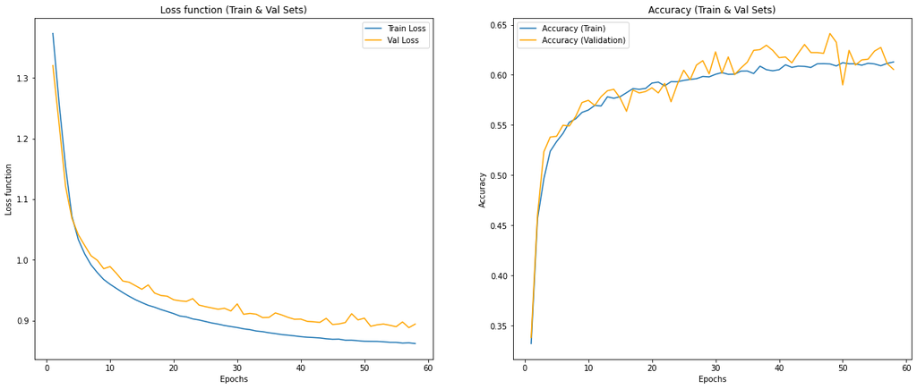

```python
plt.figure(figsize=(20,8))
loss_function = multi_class_history.history['loss']
val_loss_function = multi_class_history.history['val_loss']
epochs = range(1,len(loss_function)+1)

acc = multi_class_history.history['accuracy']
val_acc = multi_class_history.history['val_accuracy']
epochs = range(1,len(acc)+1)

plt.subplot(1, 2, 1)
plt.title('Loss function (Train & Val Sets)')
plt.plot(epochs,loss_function,label='Train Loss')
plt.plot(epochs,val_loss_function,color='orange',label='Val Loss')
plt.xlabel('Epochs')
plt.ylabel('Loss function')
plt.legend()

plt.subplot(1, 2, 2)
plt.title('Accuracy (Train & Val Sets)')
plt.plot(epochs,acc,label='Accuracy (Train)')
plt.plot(epochs,val_acc,color='orange',label='Accuracy (Validation)')
plt.xlabel('Epochs')
plt.ylabel('Accuracy')
plt.legend()
```

```python
probs = multi_classifier.predict(X_test)
truth = np.argmax(y_test, axis=1)
```

```python
predicted = np.argmax(probs, axis=1)
```

```python
df_metrics_multi = pd.DataFrame(columns=['model', 'recall', 'precision', 'weighted_accuracy', 'auc'])
recall = round(recall_score(truth, predicted, average='macro'), 4)
precision = round(precision_score(truth, predicted, average='macro'), 4)
weighted_accuracy = round(balanced_accuracy_score(truth, predicted), 4)
auc = round(roc_auc_score(truth, probs, average='macro', multi_class='ovr'), 4)
df_metrics_multi.loc[len(df_metrics_multi.index)] = ['base_model', recall, precision, weighted_accuracy, auc]
```

```python
df_metrics_multi
```

|  | model | recall | precision | weighted_accuracy | auc |
| --- | --- | --- | --- | --- | --- |
| 0 | base_model | 0.6025 | 0.5948 | 0.6025 | 0.85 |

#### Second Model

Во второй модели увеличим количество слоёв, не увиличивая число нейронов и чередуя функции активации:

1. 8 нейронов, функция активации - ReLU
2. 8 нейронов, функция активации - Sigmoid
3. 8 нейронов, функция активации - ReLU
4. 8 нейронов, функция активации - Sigmoid
5. 8 нейронов, функция активации - ReLU
6. 4 нейрона, функция активации - Softmax

```python
multi_classifier_2 = Sequential(
    [
        layers.Dense(8, activation = 'relu', input_dim = X_train.shape[1]),
        layers.Dense(8, activation = 'sigmoid'),
        layers.Dense(8, activation = 'relu'),
        layers.Dense(8, activation = 'sigmoid'),
        layers.Dense(8, activation = 'relu'),
        layers.Dense(4, activation = 'softmax')
    ]
)
multi_classifier_2.summary()
```

```
Model: "sequential_2"
_________________________________________________________________
 Layer (type)                Output Shape              Param #
=================================================================
 dense_8 (Dense)             (None, 8)                 96

 dense_9 (Dense)             (None, 8)                 72

 dense_10 (Dense)            (None, 8)                 72

 dense_11 (Dense)            (None, 8)                 72

 dense_12 (Dense)            (None, 8)                 72

 dense_13 (Dense)            (None, 4)                 36

=================================================================
Total params: 420 (1.64 KB)
Trainable params: 420 (1.64 KB)
Non-trainable params: 0 (0.00 Byte)
_________________________________________________________________
```

```python
multi_classifier_2.compile(loss = 'categorical_crossentropy', optimizer = 'adam', metrics = 'accuracy')
```

```python
early_stop = EarlyStopping(monitor = 'val_accuracy', patience = 10, mode = 'max', verbose = 1)
checkpoint = ModelCheckpoint('body_weights-{epoch:02d}-{val_accuracy:.3f}.hdf5',
                             monitor = 'val_accuracy', verbose = 1, mode = 'max',
                             save_best_only = True)
callbacks_list = [early_stop,checkpoint]
```

```python
multi_class_history = multi_classifier_2.fit(X_train, y_train, batch_size = 10, validation_data = (X_valid, y_valid),
                                        callbacks = callbacks_list, epochs = 100)
```

```
Epoch 1: val_accuracy improved from -inf to 0.37701, saving model to body_weights-01-0.377.hdf5
Epoch 2: val_accuracy improved from 0.37701 to 0.52123, saving model to body_weights-02-0.521.hdf5
Epoch 3: val_accuracy improved from 0.52123 to 0.55710, saving model to body_weights-03-0.557.hdf5
Epoch 4: val_accuracy improved from 0.55710 to 0.57101, saving model to body_weights-04-0.571.hdf5
Epoch 5: val_accuracy improved from 0.57101 to 0.57247, saving model to body_weights-05-0.572.hdf5
Epoch 6: val_accuracy improved from 0.57247 to 0.58712, saving model to body_weights-06-0.587.hdf5
Epoch 7: val_accuracy did not improve from 0.58712
Epoch 8: val_accuracy improved from 0.58712 to 0.59810, saving model to body_weights-08-0.598.hdf5
Epoch 9: val_accuracy improved from 0.59810 to 0.60615, saving model to body_weights-09-0.606.hdf5
Epoch 10: val_accuracy did not improve from 0.60615
Epoch 11: val_accuracy did not improve from 0.60615
Epoch 12: val_accuracy improved from 0.60615 to 0.62518, saving model to body_weights-12-0.625.hdf5
Epoch 13: val_accuracy did not improve from 0.62518
Epoch 14: val_accuracy did not improve from 0.62518
Epoch 15: val_accuracy improved from 0.62518 to 0.64056, saving model to body_weights-15-0.641.hdf5
Epoch 16: val_accuracy did not improve from 0.64056
Epoch 17: val_accuracy did not improve from 0.64056
Epoch 18: val_accuracy did not improve from 0.64056
Epoch 19: val_accuracy improved from 0.64056 to 0.64788, saving model to body_weights-19-0.648.hdf5
Epoch 20: val_accuracy did not improve from 0.64788
Epoch 21: val_accuracy did not improve from 0.64788
Epoch 22: val_accuracy did not improve from 0.64788
Epoch 23: val_accuracy did not improve from 0.64788
Epoch 24: val_accuracy did not improve from 0.64788
Epoch 25: val_accuracy did not improve from 0.64788
Epoch 26: val_accuracy did not improve from 0.64788
Epoch 27: val_accuracy did not improve from 0.64788
Epoch 28: val_accuracy did not improve from 0.64788
Epoch 29: val_accuracy did not improve from 0.64788
Epoch 29: early stopping
```

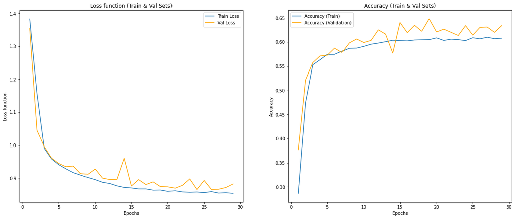

```python
plt.figure(figsize=(20,8))
loss_function = multi_class_history.history['loss']
val_loss_function = multi_class_history.history['val_loss']
epochs = range(1,len(loss_function)+1)

acc = multi_class_history.history['accuracy']
val_acc = multi_class_history.history['val_accuracy']
epochs = range(1,len(acc)+1)

plt.subplot(1, 2, 1)
plt.title('Loss function (Train & Val Sets)')
plt.plot(epochs,loss_function,label='Train Loss')
plt.plot(epochs,val_loss_function,color='orange',label='Val Loss')
plt.xlabel('Epochs')
plt.ylabel('Loss function')
plt.legend()

plt.subplot(1, 2, 2)
plt.title('Accuracy (Train & Val Sets)')
plt.plot(epochs,acc,label='Accuracy (Train)')
plt.plot(epochs,val_acc,color='orange',label='Accuracy (Validation)')
plt.xlabel('Epochs')
plt.ylabel('Accuracy')
plt.legend()
```

```python
probs = multi_classifier_2.predict(X_test)
truth = np.argmax(y_test, axis=1)
```

```python
predicted = np.argmax(probs, axis=1)
```

```python
recall = round(recall_score(truth, predicted, average='macro'), 4)
precision = round(precision_score(truth, predicted, average='macro'), 4)
weighted_accuracy = round(balanced_accuracy_score(truth, predicted), 4)
auc = round(roc_auc_score(truth, probs, average='macro', multi_class='ovr'), 4)
df_metrics_multi.loc[len(df_metrics_multi.index)] = ['second_model', recall, precision, weighted_accuracy, auc]
```

```python
df_metrics_multi
```

|  | model | recall | precision | weighted_accuracy | auc |
| --- | --- | --- | --- | --- | --- |
| 0 | base_model | 0.6025 | 0.5948 | 0.6025 | 0.8500 |
| 1 | second_model | 0.6354 | 0.6503 | 0.6354 | 0.8594 |

#### Third Model

Увеличим количество нейронов на каждом слое, кроме двух последних:

1. 64 нейрона, функция активации - ReLU
2. 64 нейрона, функция активации - Sigmoid
3. 32 нейрона, функция активации - ReLU
4. 16 нейронов, функция активации - Sigmoid
5. 8 нейронов, функция активации - ReLU
6. 4 нейрона, функция активации - Softmax

```python
multi_classifier_3 = Sequential(
    [
        layers.Dense(64, activation = 'relu', input_dim = X_train.shape[1]),
        layers.Dense(64, activation = 'sigmoid'),
        layers.Dense(32, activation = 'relu'),
        layers.Dense(16, activation = 'sigmoid'),
        layers.Dense(8, activation = 'relu'),
        layers.Dense(4, activation = 'softmax')
    ]
)
multi_classifier_3.summary()
```

```
Model: "sequential_3"
_________________________________________________________________
 Layer (type)                Output Shape              Param #
=================================================================
 dense_14 (Dense)            (None, 64)                768

 dense_15 (Dense)            (None, 64)                4160

 dense_16 (Dense)            (None, 32)                2080

 dense_17 (Dense)            (None, 16)                528

 dense_18 (Dense)            (None, 8)                 136

 dense_19 (Dense)            (None, 4)                 36

=================================================================
Total params: 7708 (30.11 KB)
Trainable params: 7708 (30.11 KB)
Non-trainable params: 0 (0.00 Byte)
_________________________________________________________________
```

```python
multi_classifier_3.compile(loss = 'categorical_crossentropy', optimizer = 'adam', metrics = 'accuracy')
```

```python
early_stop = EarlyStopping(monitor = 'val_accuracy', patience = 10, mode = 'max', verbose = 1)
checkpoint = ModelCheckpoint('body_weights-{epoch:02d}-{val_accuracy:.3f}.hdf5',
                             monitor = 'val_accuracy', verbose = 1, mode = 'max',
                             save_best_only = True)
callbacks_list = [early_stop,checkpoint]
```

Увеличим число объектов в одном батче в 10 раз и уменьшим количество эпох в 2 раза:

```python
multi_class_history = multi_classifier_3.fit(X_train, y_train, batch_size = 100, validation_data = (X_valid, y_valid),
                                        callbacks = callbacks_list, epochs = 50)
```

```
Epoch 1: val_accuracy improved from -inf to 0.34919, saving model to body_weights-01-0.349.hdf5
```

```
Epoch 2: val_accuracy improved from 0.34919 to 0.49780, saving model to body_weights-02-0.498.hdf5
Epoch 3: val_accuracy improved from 0.49780 to 0.53294, saving model to body_weights-03-0.533.hdf5
Epoch 4: val_accuracy improved from 0.53294 to 0.56515, saving model to body_weights-04-0.565.hdf5
Epoch 5: val_accuracy improved from 0.56515 to 0.58419, saving model to body_weights-05-0.584.hdf5
Epoch 6: val_accuracy improved from 0.58419 to 0.59517, saving model to body_weights-06-0.595.hdf5
Epoch 7: val_accuracy improved from 0.59517 to 0.60615, saving model to body_weights-07-0.606.hdf5
Epoch 8: val_accuracy improved from 0.60615 to 0.61493, saving model to body_weights-08-0.615.hdf5
Epoch 9: val_accuracy improved from 0.61493 to 0.63031, saving model to body_weights-09-0.630.hdf5
Epoch 10: val_accuracy did not improve from 0.63031
Epoch 11: val_accuracy did not improve from 0.63031
Epoch 12: val_accuracy improved from 0.63031 to 0.63177, saving model to body_weights-12-0.632.hdf5
Epoch 13: val_accuracy improved from 0.63177 to 0.65666, saving model to body_weights-13-0.657.hdf5
Epoch 14: val_accuracy did not improve from 0.65666
Epoch 15: val_accuracy did not improve from 0.65666
Epoch 16: val_accuracy improved from 0.65666 to 0.65813, saving model to body_weights-16-0.658.hdf5
Epoch 17: val_accuracy did not improve from 0.65813
Epoch 18: val_accuracy did not improve from 0.65813
Epoch 19: val_accuracy did not improve from 0.65813
Epoch 20: val_accuracy did not improve from 0.65813
Epoch 21: val_accuracy did not improve from 0.65813
Epoch 22: val_accuracy improved from 0.65813 to 0.66837, saving model to body_weights-22-0.668.hdf5
Epoch 23: val_accuracy improved from 0.66837 to 0.66911, saving model to body_weights-23-0.669.hdf5
Epoch 24: val_accuracy did not improve from 0.66911
Epoch 25: val_accuracy improved from 0.66911 to 0.67130, saving model to body_weights-25-0.671.hdf5
Epoch 26: val_accuracy did not improve from 0.67130
Epoch 27: val_accuracy did not improve from 0.67130
Epoch 28: val_accuracy did not improve from 0.67130
Epoch 29: val_accuracy did not improve from 0.67130
Epoch 30: val_accuracy did not improve from 0.67130
Epoch 31: val_accuracy did not improve from 0.67130
Epoch 32: val_accuracy improved from 0.67130 to 0.68375, saving model to body_weights-32-0.684.hdf5
Epoch 33: val_accuracy did not improve from 0.68375
Epoch 34: val_accuracy did not improve from 0.68375
Epoch 35: val_accuracy improved from 0.68375 to 0.68668, saving model to body_weights-35-0.687.hdf5
Epoch 36: val_accuracy did not improve from 0.68668
Epoch 37: val_accuracy did not improve from 0.68668
Epoch 38: val_accuracy did not improve from 0.68668
Epoch 39: val_accuracy did not improve from 0.68668
Epoch 40: val_accuracy did not improve from 0.68668
Epoch 41: val_accuracy did not improve from 0.68668
Epoch 42: val_accuracy did not improve from 0.68668
Epoch 43: val_accuracy did not improve from 0.68668
Epoch 44: val_accuracy did not improve from 0.68668
Epoch 45: val_accuracy did not improve from 0.68668
Epoch 45: early stopping
```

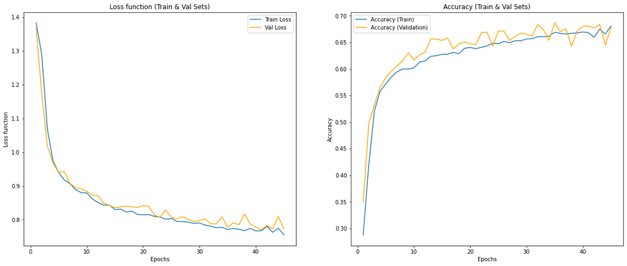

```python
plt.figure(figsize=(20,8))
loss_function = multi_class_history.history['loss']
val_loss_function = multi_class_history.history['val_loss']
epochs = range(1,len(loss_function)+1)

acc = multi_class_history.history['accuracy']
val_acc = multi_class_history.history['val_accuracy']
epochs = range(1,len(acc)+1)

plt.subplot(1, 2, 1)
plt.title('Loss function (Train & Val Sets)')
plt.plot(epochs,loss_function,label='Train Loss')
plt.plot(epochs,val_loss_function,color='orange',label='Val Loss')
plt.xlabel('Epochs')
plt.ylabel('Loss function')
plt.legend()

plt.subplot(1, 2, 2)
plt.title('Accuracy (Train & Val Sets)')
plt.plot(epochs,acc,label='Accuracy (Train)')
plt.plot(epochs,val_acc,color='orange',label='Accuracy (Validation)')
plt.xlabel('Epochs')
plt.ylabel('Accuracy')
plt.legend()
```

```python
probs = multi_classifier_3.predict(X_test)
truth = np.argmax(y_test, axis=1)
```

```python
predicted = np.argmax(probs, axis=1)
```

```python
recall = round(recall_score(truth, predicted, average='macro'), 4)
precision = round(precision_score(truth, predicted, average='macro'), 4)
weighted_accuracy = round(balanced_accuracy_score(truth, predicted), 4)
auc = round(roc_auc_score(truth, probs, average='macro', multi_class='ovr'), 4)
df_metrics_multi.loc[len(df_metrics_multi.index)] = ['third_model', recall, precision, weighted_accuracy, auc]
```

```python
df_metrics_multi
```

|  | model | recall | precision | weighted_accuracy | auc |
| --- | --- | --- | --- | --- | --- |
| 0 | base_model | 0.6025 | 0.5948 | 0.6025 | 0.8500 |
| 1 | second_model | 0.6354 | 0.6503 | 0.6354 | 0.8594 |
| 2 | third_model | 0.6826 | 0.6988 | 0.6826 | 0.8872 |

#### Fourth Model

Добавим Dropout(0.1) после нескольких первых слоёв. В первом слое увеличим количество нейронов до 128:

```python
multi_classifier_4 = Sequential(
    [
        layers.Dense(128, activation = 'relu', input_dim = X_train.shape[1]),
        layers.Dropout(0.1),
        layers.Dense(64, activation = 'sigmoid'),
        layers.Dropout(0.1),
        layers.Dense(32, activation = 'relu'),
        layers.Dense(16, activation = 'sigmoid'),
        layers.Dense(8, activation = 'relu'),
        layers.Dense(4, activation = 'softmax')
    ]
)
multi_classifier_4.summary()
```

```
Model: "sequential_7"
_________________________________________________________________
 Layer (type)                Output Shape              Param #
=================================================================
 dense_38 (Dense)            (None, 128)               1536

 dropout_7 (Dropout)         (None, 128)               0

 dense_39 (Dense)            (None, 64)                8256

 dropout_8 (Dropout)         (None, 64)                0

 dense_40 (Dense)            (None, 32)                2080

 dense_41 (Dense)            (None, 16)                528

 dense_42 (Dense)            (None, 8)                 136

 dense_43 (Dense)            (None, 4)                 36

=================================================================
Total params: 12572 (49.11 KB)
Trainable params: 12572 (49.11 KB)
Non-trainable params: 0 (0.00 Byte)
_________________________________________________________________
```

Изменим процедуру оптимизации на RMSprop:

```python
multi_classifier_4.compile(loss = 'categorical_crossentropy', optimizer = 'RMSprop', metrics = 'accuracy')
```

```python
early_stop = EarlyStopping(monitor = 'val_accuracy', patience = 10, mode = 'max', verbose = 1)
checkpoint = ModelCheckpoint('body_weights-{epoch:02d}-{val_accuracy:.3f}.hdf5',
                             monitor = 'val_accuracy', verbose = 1, mode = 'max',
                             save_best_only = True)
callbacks_list = [early_stop,checkpoint]
```

Увеличим количество эпох в 2 раза:

```python
multi_class_history = multi_classifier_4.fit(X_train, y_train, batch_size = 100, validation_data = (X_valid, y_valid),
                                        callbacks = callbacks_list, epochs = 100)
```

```
Epoch 1: val_accuracy improved from -inf to 0.24524, saving model to body_weights-01-0.245.hdf5
Epoch 2: val_accuracy improved from 0.24524 to 0.28990, saving model to body_weights-02-0.290.hdf5
Epoch 3: val_accuracy improved from 0.28990 to 0.34261, saving model to body_weights-03-0.343.hdf5
Epoch 4: val_accuracy improved from 0.34261 to 0.38141, saving model to body_weights-04-0.381.hdf5
Epoch 5: val_accuracy improved from 0.38141 to 0.41435, saving model to body_weights-05-0.414.hdf5
Epoch 6: val_accuracy improved from 0.41435 to 0.50586, saving model to body_weights-06-0.506.hdf5
Epoch 7: val_accuracy improved from 0.50586 to 0.54173, saving model to body_weights-07-0.542.hdf5
Epoch 8: val_accuracy improved from 0.54173 to 0.56515, saving model to body_weights-08-0.565.hdf5
Epoch 9: val_accuracy did not improve from 0.56515
Epoch 10: val_accuracy did not improve from 0.56515
Epoch 11: val_accuracy improved from 0.56515 to 0.58712, saving model to body_weights-11-0.587.hdf5
Epoch 12: val_accuracy did not improve from 0.58712
Epoch 13: val_accuracy did not improve from 0.58712
Epoch 14: val_accuracy improved from 0.58712 to 0.59736, saving model to body_weights-14-0.597.hdf5
Epoch 15: val_accuracy did not improve from 0.59736
Epoch 16: val_accuracy did not improve from 0.59736
Epoch 17: val_accuracy did not improve from 0.59736
Epoch 18: val_accuracy improved from 0.59736 to 0.60542, saving model to body_weights-18-0.605.hdf5
Epoch 19: val_accuracy did not improve from 0.60542
Epoch 20: val_accuracy did not improve from 0.60542
Epoch 21: val_accuracy improved from 0.60542 to 0.60981, saving model to body_weights-21-0.610.hdf5
Epoch 22: val_accuracy did not improve from 0.60981
Epoch 23: val_accuracy did not improve from 0.60981
Epoch 24: val_accuracy did not improve from 0.60981
Epoch 25: val_accuracy did not improve from 0.60981
Epoch 26: val_accuracy improved from 0.60981 to 0.61274, saving model to body_weights-26-0.613.hdf5
Epoch 27: val_accuracy improved from 0.61274 to 0.61786, saving model to body_weights-27-0.618.hdf5
Epoch 28: val_accuracy did not improve from 0.61786
Epoch 29: val_accuracy did not improve from 0.61786
Epoch 30: val_accuracy did not improve from 0.61786
Epoch 31: val_accuracy improved from 0.61786 to 0.61859, saving model to body_weights-31-0.619.hdf5
Epoch 32: val_accuracy did not improve from 0.61859
Epoch 33: val_accuracy improved from 0.61859 to 0.63104, saving model to body_weights-33-0.631.hdf5
Epoch 34: val_accuracy did not improve from 0.63104
Epoch 35: val_accuracy improved from 0.63104 to 0.63177, saving model to body_weights-35-0.632.hdf5
Epoch 36: val_accuracy did not improve from 0.63177
Epoch 37: val_accuracy did not improve from 0.63177
Epoch 38: val_accuracy did not improve from 0.63177
Epoch 39: val_accuracy improved from 0.63177 to 0.63324, saving model to body_weights-39-0.633.hdf5
Epoch 40: val_accuracy did not improve from 0.63324
```

[output cut: 45 more lines]

```
Epoch 86: val_accuracy did not improve from 0.69107
Epoch 87: val_accuracy did not improve from 0.69107
Epoch 88: val_accuracy did not improve from 0.69107
Epoch 89: val_accuracy did not improve from 0.69107
Epoch 90: val_accuracy improved from 0.69107 to 0.70205, saving model to body_weights-90-0.702.hdf5
Epoch 91: val_accuracy did not improve from 0.70205
Epoch 92: val_accuracy did not improve from 0.70205
Epoch 93: val_accuracy did not improve from 0.70205
Epoch 94: val_accuracy did not improve from 0.70205
Epoch 95: val_accuracy did not improve from 0.70205
Epoch 96: val_accuracy did not improve from 0.70205
Epoch 97: val_accuracy did not improve from 0.70205
Epoch 98: val_accuracy did not improve from 0.70205
Epoch 99: val_accuracy did not improve from 0.70205
Epoch 100: val_accuracy improved from 0.70205 to 0.70937, saving model to body_weights-100-0.709.hdf5
```

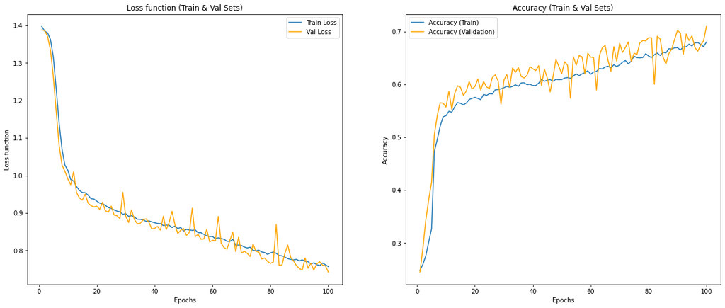

```python
plt.figure(figsize=(20,8))
loss_function = multi_class_history.history['loss']
val_loss_function = multi_class_history.history['val_loss']
epochs = range(1,len(loss_function)+1)

acc = multi_class_history.history['accuracy']
val_acc = multi_class_history.history['val_accuracy']
epochs = range(1,len(acc)+1)

plt.subplot(1, 2, 1)
plt.title('Loss function (Train & Val Sets)')
plt.plot(epochs,loss_function,label='Train Loss')
plt.plot(epochs,val_loss_function,color='orange',label='Val Loss')
plt.xlabel('Epochs')
plt.ylabel('Loss function')
plt.legend()

plt.subplot(1, 2, 2)
plt.title('Accuracy (Train & Val Sets)')
plt.plot(epochs,acc,label='Accuracy (Train)')
plt.plot(epochs,val_acc,color='orange',label='Accuracy (Validation)')
plt.xlabel('Epochs')
plt.ylabel('Accuracy')
plt.legend()
```

```python
probs = multi_classifier_4.predict(X_test)
truth = np.argmax(y_test, axis=1)
```

```python
predicted = np.argmax(probs, axis=1)
```

```python
recall = round(recall_score(truth, predicted, average='macro'), 4)
precision = round(precision_score(truth, predicted, average='macro'), 4)
weighted_accuracy = round(balanced_accuracy_score(truth, predicted), 4)
auc = round(roc_auc_score(truth, probs, average='macro', multi_class='ovr'), 4)
df_metrics_multi.loc[len(df_metrics_multi.index)] = ['fourth_model', recall, precision, weighted_accuracy, auc]
```

```python
df_metrics_multi
```

|  | model | recall | precision | weighted_accuracy | auc |
| --- | --- | --- | --- | --- | --- |
| 0 | base_model | 0.6025 | 0.5948 | 0.6025 | 0.8500 |
| 1 | second_model | 0.6354 | 0.6503 | 0.6354 | 0.8594 |
| 2 | third_model | 0.6826 | 0.6988 | 0.6826 | 0.8872 |
| 3 | fourth_model | 0.7032 | 0.7200 | 0.7032 | 0.8967 |

Анализируя полученные метрики 4-х моделей, можно сделать вывод, что наилучшим многоклассовым классификатором является Fourth Model.

Построим ROC-кривую для каждого класса в данной модели:

```python
probs_4 = multi_classifier_4.predict(X_test)
truth = np.argmax(y_test, axis=1)
```

Выведем графики ROC-кривой отдельного для каждого класса:

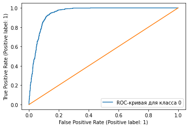

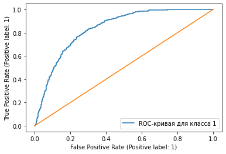

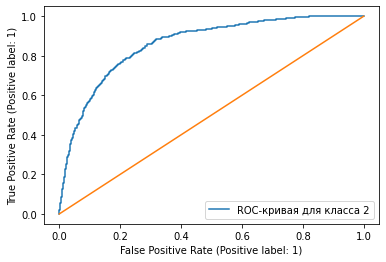

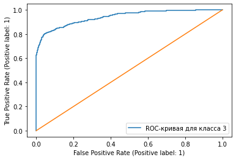

```python
for i in range(0, 4):
    RocCurveDisplay.from_predictions(
        y_test[:, i],
        probs_4[:, i],
        label = f"ROC-кривая для класса {i}"
    )
    x = np.linspace(0, 1, 10)
    y = x
    plt.plot(x,y)
plt.show()
```

Построим ROC-кривые для каждого класса на одном графике:

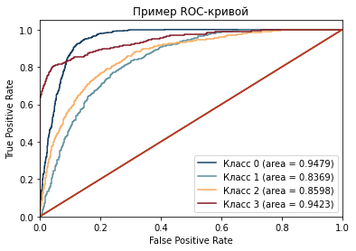

```python
colors = ['#173f61', '#5b8f9a', '#faab5c', '#841826']
for i in range (0, 4):
    fpr, tpr, treshold = roc_curve(y_test[:,i], probs_4[:,i])
    auc = round(roc_auc_score(y_test[:,i], probs_4[:,i]), 4)
    plt.plot(fpr, tpr, label=f"Класс {i} (area = {auc})", color = colors[i])
    plt.plot([0, 1], [0, 1])
plt.xlim([0.0, 1.0])
plt.ylim([0.0, 1.05])
plt.xlabel('False Positive Rate')
plt.ylabel('True Positive Rate')
plt.title('Пример ROC-кривой')
plt.legend(loc="lower right")
plt.show()
```

### Вывод

Набор данных 'bodyPerformance.csv' не содержал пропущенных значений, но в нем присутствовал дубликат, который был удален. Значения в столбцах gender и class были закодированы.

Среди четырёх моделей многоклассовых классификаторов лучше всего сработала Fourth Model. В ней увеличено число слоёв и нейронов на каждом слое по сравнению с Base Model, добавлен Dropout(0.1) после двух первых слоёв и используется процедура оптимизации RMSprop.

Оценка качества многоклассовых классификаторов происходила по следующим метрикам: Recall, Precision, Weighted Accuracy и AUC. Эти показатели у Fourth Model выше, чем у остальных моделей.

### Задание №3

### Работа с данными

```python
df = pd.read_csv('DS_2019_public.csv', encoding = "windows-1251")
df.head()
```

|  | Climate_Region_Pub | DIVISION | REPORTABLE_DOMAIN | DOLELCOL | TOTALDOLCOL | KWHCOL | BTUELCOL | TOTALBTUCOL | TOTALDOLSPH | TOTALBTUSPH | ... | LGT1EE | TOTALBTUWTH | ROOFTYPE | DOLELRFG | TOTALDOLRFG | HEATROOM | WDWATER | UGWARM | DRYRFUEL | KWHRFG |
| --- | --- | --- | --- | --- | --- | --- | --- | --- | --- | --- | --- | --- | --- | --- | --- | --- | --- | --- | --- | --- | --- |
| 0 | 5 | 10 | 26 | 16.793 | 17 | 181.998 | 620.979 | 621 | 368 | 38606 | ... | -2 | 30110 | 2 | 120.893 | 121 | 4 | 0 | 1 | 1 | 1310.220 |
| 1 | 1 | 1 | 1 | 48.901 | 49 | 184.459 | 629.389 | 629 | 582 | 40248 | ... | 2 | 7933 | -2 | 242.746 | 243 | 2 | 0 | 1 | -2 | 915.664 |
| 2 | 1 | 3 | 7 | 101.048 | 101 | 1063.022 | 3627.013 | 3627 | 425 | 40196 | ... | -2 | 6440 | 5 | 158.797 | 159 | 7 | 0 | 1 | 5 | 1670.534 |
| 3 | 1 | 1 | 1 | 0 | 0 | 0.000 | 0.000 | 0 | 616 | 36136 | ... | 2 | 13884 | 5 | 85.138 | 85 | 5 | 0 | 1 | 5 | 346.468 |
| 4 | 1 | 4 | 10 | 45.132 | 45 | 274.530 | 936.677 | 937 | 685 | 74100 | ... | 3 | 14204 | 6 | 151.319 | 151 | 6 | 0 | 1 | 5 | 920.454 |

5 rows × 121 columns

```python
df.shape
```

```
(10875, 121)
```

```python
for i in df.columns:
    if df[i].isnull().sum() > 0:
        print(df[i].isnull().sum()/df.shape[0])
    else:
        print('Пропусков нет: ', i)
```

```
Пропусков нет:  Climate_Region_Pub
Пропусков нет:  DIVISION
Пропусков нет:  REPORTABLE_DOMAIN
Пропусков нет:  DOLELCOL
Пропусков нет:  TOTALDOLCOL
Пропусков нет:  KWHCOL
Пропусков нет:  BTUELCOL
Пропусков нет:  TOTALBTUCOL
Пропусков нет:  TOTALDOLSPH
Пропусков нет:  TOTALBTUSPH
Пропусков нет:  CELLAR
Пропусков нет:  NWEIGHT
Пропусков нет:  TOTHSQFT
Пропусков нет:  HEATHOME
Пропусков нет:  NUMPC
Пропусков нет:  DOLLAREL
Пропусков нет:  DOLELOTH
Пропусков нет:  CUFEETNGSPH
Пропусков нет:  BTUNGSPH
Пропусков нет:  DOLNGSPH
Пропусков нет:  TEMPHOME
Пропусков нет:  TOTCSQFT
Пропусков нет:  BTUFOSPH
Пропусков нет:  AIRCOND
Пропусков нет:  ELCOOL
Пропусков нет:  GALLONFOSPH
Пропусков нет:  WALLTYPE
Пропусков нет:  TOTALDOLOTH
Пропусков нет:  BTUFO
Пропусков нет:  GALLONFO
Пропусков нет:  DOLFOSPH
Пропусков нет:  DOLLARFO
Пропусков нет:  KWHSPH
Пропусков нет:  BTUELSPH
Пропусков нет:  FOWARM
Пропусков нет:  USEFO
Пропусков нет:  TOTUSQFT
Пропусков нет:  TOTALDOL
Пропусков нет:  NUMTHERM
Пропусков нет:  DOLELSPH
```

[output cut: 66 more lines]

```
Пропусков нет:  CUFEETNGWTH
Пропусков нет:  BTUNGWTH
Пропусков нет:  UGWATER
Пропусков нет:  SDESCENT
Пропусков нет:  TEMPGONE
Пропусков нет:  LGT1EE
Пропусков нет:  TOTALBTUWTH
Пропусков нет:  ROOFTYPE
Пропусков нет:  DOLELRFG
Пропусков нет:  TOTALDOLRFG
Пропусков нет:  HEATROOM
Пропусков нет:  WDWATER
Пропусков нет:  UGWARM
Пропусков нет:  DRYRFUEL
Пропусков нет:  KWHRFG
```

```python
#Пропусков нет
df.isnull().sum()/df.shape[0]
```

```
Climate_Region_Pub    0.0
DIVISION              0.0
REPORTABLE_DOMAIN     0.0
DOLELCOL              0.0
TOTALDOLCOL           0.0
                     ...
HEATROOM              0.0
WDWATER               0.0
UGWARM                0.0
DRYRFUEL              0.0
KWHRFG                0.0
Length: 121, dtype: float64
```

```python
df.info(verbose=True, show_counts=True)
```

```
<class 'pandas.core.frame.DataFrame'>
RangeIndex: 10875 entries, 0 to 10874
Data columns (total 121 columns):
 #    Column              Non-Null Count  Dtype
---   ------              --------------  -----
 0    Climate_Region_Pub  10875 non-null  int64
 1    DIVISION            10875 non-null  int64
 2    REPORTABLE_DOMAIN   10875 non-null  int64
 3    DOLELCOL            10875 non-null  object
 4    TOTALDOLCOL         10875 non-null  int64
 5    KWHCOL              10875 non-null  float64
 6    BTUELCOL            10875 non-null  float64
 7    TOTALBTUCOL         10875 non-null  int64
 8    TOTALDOLSPH         10875 non-null  int64
 9    TOTALBTUSPH         10875 non-null  int64
```

[output cut: 113 more lines]

Посмотрим, что находится в столбцах типа object:

```python
types = df.dtypes
types = types.loc[types == "object"]
```

```python
for i in types.index:
    print(i)
    print(df[i].unique())
```

[output not shown]

[output cut: 42 more lines]

```
 '2236.764' '771' '708' '1729.981' '936.716' '903.735' '952.62' '1252.873'
 '2414.04' '748' '793' '1413.109' '3009.596' '1029.688' '1689.47'
 '1277.298' '703' '836' '1719.033']
DOLELSPH
['0' '96.919' '189.962' ... '274.159' '347.094' '11.302']
DOLNGWTH
[286.745 114.618 0.0 ... '204.148' '107.694' '83.939']
CUFEETNGOTH
['167.601' '28.944' '19.848' ... '53.564' '192.014' '32.81']
KWHOTH
[3655.782 1117.878 5393.913 ... '6813.645' '2812.665' '1249.354']
CUFEETNGWTH
['293.756' '77.394' '0' ... '237.96' '121.133' '78.21']
DOLELRFG
['120.893' '242.746' '158.797' ... 250.313 175.135 49.364]
```

Столбцы типа object в основном состоят из числовых значений. Скорее всего, там присутствуют выбросы. Переведем в float все возможные значениях в данных столбцах. Если так сделать нельзя - значение удаляем:

```python
def convert_to_float(x):
    try:
        return float(x)
    except:
        return np.nan
```

```python
for i in types.index:
    df[i] = df[i].apply(lambda x: convert_to_float(x))
    print(i)
    print(df[i].isnull().sum())
```

```
DOLELCOL
70
DOLFOSPH
1
DOLELSPH
4
DOLNGWTH
2
CUFEETNGOTH
12
KWHOTH
1
CUFEETNGWTH
3
DOLELRFG
1
```

Удаляем строки с пропущенными значениями:

```python
df.dropna(inplace=True)
df.shape
```

```
(10785, 121)
```

```python
#Дубликатов нет
df = df.drop_duplicates()
df.shape
```

```
(10785, 121)
```

```python
df.describe()
```

|  | Climate_Region_Pub | DIVISION | REPORTABLE_DOMAIN | DOLELCOL | TOTALDOLCOL | KWHCOL | BTUELCOL | TOTALBTUCOL | TOTALDOLSPH | TOTALBTUSPH | ... | LGT1EE | TOTALBTUWTH | ROOFTYPE | DOLELRFG | TOTALDOLRFG | HEATROOM | WDWATER | UGWARM | DRYRFUEL | KWHRFG |
| --- | --- | --- | --- | --- | --- | --- | --- | --- | --- | --- | --- | --- | --- | --- | --- | --- | --- | --- | --- | --- | --- |
| count | 10785.000000 | 10785.000000 | 10785.000000 | 10785.000000 | 10785.000000 | 10785.000000 | 10785.000000 | 10785.000000 | 10785.000000 | 10785.000000 | ... | 10785.000000 | 10785.000000 | 10785.000000 | 10785.000000 | 10785.000000 | 10785.000000 | 10785.000000 | 10785.000000 | 10785.000000 | 10785.000000 |
| mean | 2.608067 | 5.376263 | 14.798146 | 203.750405 | 203.749652 | 1693.624306 | 5778.645776 | 5778.642281 | 561.049235 | 36878.418730 | ... | 0.818173 | 16344.560779 | 3.673621 | 154.725129 | 154.728234 | 5.349096 | 0.000834 | 0.500788 | 2.984979 | 1246.633642 |
| std | 1.347541 | 2.859324 | 8.199397 | 311.318456 | 311.321580 | 2485.590453 | 8480.833423 | 8480.830656 | 505.514181 | 35826.928857 | ... | 2.350035 | 13755.839203 | 2.773690 | 107.181736 | 107.184538 | 2.639938 | 0.028877 | 0.500023 | 2.840688 | 778.412482 |
| min | 1.000000 | 1.000000 | 1.000000 | 0.000000 | 0.000000 | 0.000000 | 0.000000 | 0.000000 | 0.000000 | 0.000000 | ... | -9.000000 | 0.000000 | -2.000000 | 0.000000 | 0.000000 | -2.000000 | 0.000000 | 0.000000 | -2.000000 | 0.000000 |
| 25% | 1.000000 | 3.000000 | 8.000000 | 19.413000 | 19.000000 | 150.993000 | 515.182000 | 515.000000 | 222.000000 | 8713.000000 | ... | 0.000000 | 7718.000000 | 2.000000 | 86.393000 | 86.000000 | 4.000000 | 0.000000 | 0.000000 | 1.000000 | 725.791000 |
| 50% | 3.000000 | 5.000000 | 16.000000 | 90.775000 | 91.000000 | 763.090000 | 2603.690000 | 2604.000000 | 430.000000 | 27209.000000 | ... | 0.000000 | 12778.000000 | 5.000000 | 127.090000 | 127.000000 | 5.000000 | 0.000000 | 1.000000 | 5.000000 | 1049.151000 |
| 75% | 4.000000 | 7.000000 | 21.000000 | 264.527000 | 265.000000 | 2303.045000 | 7858.013000 | 7858.000000 | 762.000000 | 55719.000000 | ... | 2.000000 | 21193.000000 | 5.000000 | 192.992000 | 193.000000 | 7.000000 | 0.000000 | 1.000000 | 5.000000 | 1561.557000 |
| max | 5.000000 | 10.000000 | 27.000000 | 7729.265000 | 7729.000000 | 60995.431000 | 208116.552000 | 208117.000000 | 9264.000000 | 548711.000000 | ... | 40.000000 | 284130.000000 | 8.000000 | 2490.046000 | 2490.000000 | 23.000000 | 1.000000 | 1.000000 | 5.000000 | 11069.027000 |

8 rows × 121 columns

В некоторых столбцах присутствуют выбросы в виде отрицательных значений. Удалим такие значения:

```python
for i in df.columns:
    df.loc[df[i]<0, i] = np.nan
    if (df[i].isnull().sum()/df.shape[0])>0:
        print(i)
        print(df[i].isnull().sum()/df.shape[0])
```

```
CELLAR
0.20407974038015764
TEMPHOME
0.03801576263328697
NUMTHERM
0.15159944367176634
CONCRETE
0.20407974038015764
BEDROOMS
0.0181733889661567
FUELHEAT
0.03801576263328697
COOLTYPE
0.17923041261010664
DOOR1SUM
9.27213722763097e-05
EQUIPM
0.03801576263328697
STORIES
0.23532684283727398
FUELH2O
0.0028743625405656
TEMPGONE
0.03801576263328697
LGT1EE
0.16430227167362077
ROOFTYPE
0.15957348168752897
HEATROOM
0.03801576263328697
DRYRFUEL
0.19499304589707928
```

Появились столбцы с пропущенными значениями. Удалим столбцы с процентом NaN больше 5%. В остальных удалим строки с пропущенными значениям:

```python
for i in df.columns:
    if (df[i].isnull().sum()/df.shape[0])>=0.05:
        df = df.drop(i, axis=1)
```

```python
df.shape
```

```
(10785, 113)
```

```python
df.dropna(inplace=True)
```

```python
#Пропущенных значений нет
df.isnull().sum().sum()
```

```
0
```

```python
df.head()
```

|  | Climate_Region_Pub | DIVISION | REPORTABLE_DOMAIN | DOLELCOL | TOTALDOLCOL | KWHCOL | BTUELCOL | TOTALBTUCOL | TOTALDOLSPH | TOTALBTUSPH | ... | UGWATER | SDESCENT | TEMPGONE | TOTALBTUWTH | DOLELRFG | TOTALDOLRFG | HEATROOM | WDWATER | UGWARM | KWHRFG |
| --- | --- | --- | --- | --- | --- | --- | --- | --- | --- | --- | --- | --- | --- | --- | --- | --- | --- | --- | --- | --- | --- |
| 0 | 5.0 | 10.0 | 26.0 | 16.793 | 17.0 | 181.998 | 620.979 | 621.0 | 368.0 | 38606.0 | ... | 1.0 | 0.0 | 70.0 | 30110.0 | 120.893 | 121.0 | 4.0 | 0.0 | 1.0 | 1310.220 |
| 1 | 1.0 | 1.0 | 1.0 | 48.901 | 49.0 | 184.459 | 629.389 | 629.0 | 582.0 | 40248.0 | ... | 1.0 | 0.0 | 60.0 | 7933.0 | 242.746 | 243.0 | 2.0 | 0.0 | 1.0 | 915.664 |
| 2 | 1.0 | 3.0 | 7.0 | 101.048 | 101.0 | 1063.022 | 3627.013 | 3627.0 | 425.0 | 40196.0 | ... | 0.0 | 0.0 | 55.0 | 6440.0 | 158.797 | 159.0 | 7.0 | 0.0 | 1.0 | 1670.534 |
| 3 | 1.0 | 1.0 | 1.0 | 0.000 | 0.0 | 0.000 | 0.000 | 0.0 | 616.0 | 36136.0 | ... | 1.0 | 0.0 | 70.0 | 13884.0 | 85.138 | 85.0 | 5.0 | 0.0 | 1.0 | 346.468 |
| 4 | 1.0 | 4.0 | 10.0 | 45.132 | 45.0 | 274.530 | 936.677 | 937.0 | 685.0 | 74100.0 | ... | 1.0 | 0.0 | 66.0 | 14204.0 | 151.319 | 151.0 | 6.0 | 0.0 | 1.0 | 920.454 |

5 rows × 113 columns

```python
X = df.drop(['TOTALDOL'],axis=1)
y = df['TOTALDOL']
```

```python
min_max_scaler = MinMaxScaler()
X = min_max_scaler.fit_transform(X)
```

Разделим датасет на три части: тренировочную (70%), тестовую (20%) и валидационную (10%).

```python
X_train, X_rem, y_train, y_rem = train_test_split(X, y, train_size=0.7, random_state=77)

X_valid, X_test, y_valid, y_test = train_test_split(X_rem, y_rem, test_size=0.66, random_state=77)
```

### Создание моделей

#### Base Model

Создадим базовую модель нейронной сети, состоящую из 2 слоёв:

1. 16 нейронов, функция активации - ReLU
2. 1 нейрон

```python
regressor = Sequential(
    [
        layers.Dense(16, activation = 'relu', input_dim = X_train.shape[1]),
        layers.Dense(1)
    ]
)
regressor.summary()
```

```
Model: "sequential_4"
_________________________________________________________________
 Layer (type)                Output Shape              Param #
=================================================================
 dense_8 (Dense)             (None, 16)                1808

 dense_9 (Dense)             (None, 1)                 17

=================================================================
Total params: 1825 (7.13 KB)
Trainable params: 1825 (7.13 KB)
Non-trainable params: 0 (0.00 Byte)
_________________________________________________________________
```

```python
regressor.compile(loss = 'mean_squared_error', optimizer = 'adam')
```

Будем отслеживать уменьшение функции потерь:

```python
early_stop = EarlyStopping(monitor = 'val_loss', patience = 10, mode = 'min', verbose =1)
checkpoint = ModelCheckpoint('household-{epoch:02d}-{val_loss:.3f}.hdf5',
                             monitor = 'val_loss', verbose = 1, mode = 'min',
                             save_best_only = True)
callbacks_list = [early_stop,checkpoint]
```

Возьмем количество эпох в 2 раза больше, чем мы использовали в классификаторах:

```python
regressor_history = regressor.fit(X_train, y_train, batch_size = 10, validation_data = (X_valid, y_valid),
                                        callbacks = callbacks_list, epochs = 200)
```

```
Epoch 1: val_loss improved from inf to 5189722.50000, saving model to household-01-5189722.500.hdf5
```

```
Epoch 2: val_loss improved from 5189722.50000 to 4020010.75000, saving model to household-02-4020010.750.hdf5
Epoch 3: val_loss improved from 4020010.75000 to 2739178.50000, saving model to household-03-2739178.500.hdf5
Epoch 4: val_loss improved from 2739178.50000 to 1772570.87500, saving model to household-04-1772570.875.hdf5
Epoch 5: val_loss improved from 1772570.87500 to 1219848.00000, saving model to household-05-1219848.000.hdf5
Epoch 6: val_loss improved from 1219848.00000 to 1005385.25000, saving model to household-06-1005385.250.hdf5
Epoch 7: val_loss improved from 1005385.25000 to 931083.37500, saving model to household-07-931083.375.hdf5
Epoch 8: val_loss improved from 931083.37500 to 884063.93750, saving model to household-08-884063.938.hdf5
Epoch 9: val_loss improved from 884063.93750 to 841152.81250, saving model to household-09-841152.812.hdf5
Epoch 10: val_loss improved from 841152.81250 to 798644.00000, saving model to household-10-798644.000.hdf5
Epoch 11: val_loss improved from 798644.00000 to 758523.37500, saving model to household-11-758523.375.hdf5
Epoch 12: val_loss improved from 758523.37500 to 720863.43750, saving model to household-12-720863.438.hdf5
Epoch 13: val_loss improved from 720863.43750 to 685263.25000, saving model to household-13-685263.250.hdf5
Epoch 14: val_loss improved from 685263.25000 to 651291.56250, saving model to household-14-651291.562.hdf5
Epoch 15: val_loss improved from 651291.56250 to 617702.56250, saving model to household-15-617702.562.hdf5
Epoch 16: val_loss improved from 617702.56250 to 586514.56250, saving model to household-16-586514.562.hdf5
Epoch 17: val_loss improved from 586514.56250 to 558378.25000, saving model to household-17-558378.250.hdf5
Epoch 18: val_loss improved from 558378.25000 to 533507.37500, saving model to household-18-533507.375.hdf5
Epoch 19: val_loss improved from 533507.37500 to 509524.00000, saving model to household-19-509524.000.hdf5
Epoch 20: val_loss improved from 509524.00000 to 486850.68750, saving model to household-20-486850.688.hdf5
Epoch 21: val_loss improved from 486850.68750 to 466576.87500, saving model to household-21-466576.875.hdf5
Epoch 22: val_loss improved from 466576.87500 to 448053.68750, saving model to household-22-448053.688.hdf5
Epoch 23: val_loss improved from 448053.68750 to 429126.50000, saving model to household-23-429126.500.hdf5
Epoch 24: val_loss improved from 429126.50000 to 413147.68750, saving model to household-24-413147.688.hdf5
Epoch 25: val_loss improved from 413147.68750 to 397445.68750, saving model to household-25-397445.688.hdf5
Epoch 26: val_loss improved from 397445.68750 to 382487.06250, saving model to household-26-382487.062.hdf5
Epoch 27: val_loss improved from 382487.06250 to 368911.34375, saving model to household-27-368911.344.hdf5
Epoch 28: val_loss improved from 368911.34375 to 356015.15625, saving model to household-28-356015.156.hdf5
Epoch 29: val_loss improved from 356015.15625 to 343733.43750, saving model to household-29-343733.438.hdf5
Epoch 30: val_loss improved from 343733.43750 to 332279.40625, saving model to household-30-332279.406.hdf5
Epoch 31: val_loss improved from 332279.40625 to 320668.84375, saving model to household-31-320668.844.hdf5
Epoch 32: val_loss improved from 320668.84375 to 310085.25000, saving model to household-32-310085.250.hdf5
Epoch 33: val_loss improved from 310085.25000 to 300122.21875, saving model to household-33-300122.219.hdf5
Epoch 34: val_loss improved from 300122.21875 to 290474.96875, saving model to household-34-290474.969.hdf5
Epoch 35: val_loss improved from 290474.96875 to 280442.96875, saving model to household-35-280442.969.hdf5
Epoch 36: val_loss improved from 280442.96875 to 271343.25000, saving model to household-36-271343.250.hdf5
Epoch 37: val_loss improved from 271343.25000 to 262869.09375, saving model to household-37-262869.094.hdf5
Epoch 38: val_loss improved from 262869.09375 to 254894.51562, saving model to household-38-254894.516.hdf5
Epoch 39: val_loss improved from 254894.51562 to 247194.14062, saving model to household-39-247194.141.hdf5
Epoch 40: val_loss improved from 247194.14062 to 239572.10938, saving model to household-40-239572.109.hdf5
Epoch 41: val_loss improved from 239572.10938 to 232507.81250, saving model to household-41-232507.812.hdf5
```

[output cut: 144 more lines]

```
Epoch 186: val_loss improved from 10810.47461 to 10612.46680, saving model to household-186-10612.467.hdf5
Epoch 187: val_loss improved from 10612.46680 to 10501.01172, saving model to household-187-10501.012.hdf5
Epoch 188: val_loss did not improve from 10501.01172
Epoch 189: val_loss improved from 10501.01172 to 10210.24121, saving model to household-189-10210.241.hdf5
Epoch 190: val_loss improved from 10210.24121 to 9989.15625, saving model to household-190-9989.156.hdf5
Epoch 191: val_loss improved from 9989.15625 to 9823.66309, saving model to household-191-9823.663.hdf5
Epoch 192: val_loss improved from 9823.66309 to 9817.23242, saving model to household-192-9817.232.hdf5
Epoch 193: val_loss improved from 9817.23242 to 9534.41895, saving model to household-193-9534.419.hdf5
Epoch 194: val_loss improved from 9534.41895 to 9345.21094, saving model to household-194-9345.211.hdf5
Epoch 195: val_loss improved from 9345.21094 to 9222.95020, saving model to household-195-9222.950.hdf5
Epoch 196: val_loss did not improve from 9222.95020
Epoch 197: val_loss improved from 9222.95020 to 9051.80469, saving model to household-197-9051.805.hdf5
Epoch 198: val_loss improved from 9051.80469 to 8844.80957, saving model to household-198-8844.810.hdf5
Epoch 199: val_loss improved from 8844.80957 to 8755.33008, saving model to household-199-8755.330.hdf5
Epoch 200: val_loss improved from 8755.33008 to 8575.19238, saving model to household-200-8575.192.hdf5
```

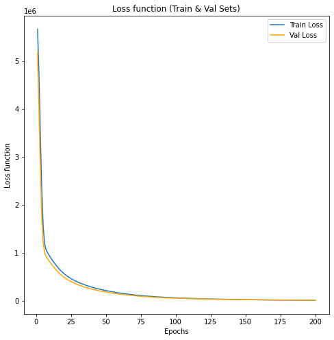

```python
plt.figure(figsize=(8,8))
loss_function = regressor_history.history['loss']
val_loss_function = regressor_history.history['val_loss']
epochs = range(1,len(loss_function)+1)

plt.title('Loss function (Train & Val Sets)')
plt.plot(epochs,loss_function,label='Train Loss')
plt.plot(epochs,val_loss_function,color='orange',label='Val Loss')
plt.xlabel('Epochs')
plt.ylabel('Loss function')
plt.legend()
```

```python
probs = regressor.predict(X_test)
truth = y_test
```

```python
df_metrics_regress = pd.DataFrame(columns=['model', 'mse', 'mae', 'r2'])
mse = round(mean_squared_error(probs, truth), 3)
mae = round(mean_absolute_error(probs, truth), 3)
r2 = round(r2_score(probs, truth), 5)
df_metrics_regress.loc[len(df_metrics_regress.index)] = ['base_model', mse, mae, r2]
```

```python
df_metrics_regress
```

|  | model | mse | mae | r2 |
| --- | --- | --- | --- | --- |
| 0 | base_model | 6439.512 | 51.051 | 0.99453 |

#### Second Model

Во второй модели увеличим количество слоёв, не увиличивая число нейронов и чередуя функции активации:

1. 16 нейронов, функция активации - ReLU
2. 16 нейронов, функция активации - Sigmoid
3. 16 нейронов, функция активации - SeLU
4. 16 нейронов, функция активации - Sigmoid
5. 16 нейронов, функция активации - ReLU
6. 1 нейрон

```python
regressor_2 = Sequential(
    [
        layers.Dense(16, activation = 'relu', input_dim = X_train.shape[1]),
        layers.Dense(16, activation = 'sigmoid'),
        layers.Dense(16, activation = 'selu'),
        layers.Dense(16, activation = 'sigmoid'),
        layers.Dense(16, activation = 'relu'),
        layers.Dense(1)
    ]
)
regressor_2.summary()
```

```
Model: "sequential_5"
_________________________________________________________________
 Layer (type)                Output Shape              Param #
=================================================================
 dense_10 (Dense)            (None, 16)                1808

 dense_11 (Dense)            (None, 16)                272

 dense_12 (Dense)            (None, 16)                272

 dense_13 (Dense)            (None, 16)                272

 dense_14 (Dense)            (None, 16)                272

 dense_15 (Dense)            (None, 1)                 17

=================================================================
Total params: 2913 (11.38 KB)
Trainable params: 2913 (11.38 KB)
Non-trainable params: 0 (0.00 Byte)
_________________________________________________________________
```

```python
regressor_2.compile(loss = 'mean_squared_error', optimizer = 'adam')
```

```python
early_stop = EarlyStopping(monitor = 'val_loss', patience = 10, mode = 'min', verbose =1)
checkpoint = ModelCheckpoint('household_2-{epoch:02d}-{val_loss:.3f}.hdf5',
                             monitor = 'val_loss', verbose = 1, mode = 'min',
                             save_best_only = True)
callbacks_list = [early_stop,checkpoint]
```

```python
regressor_history = regressor_2.fit(X_train, y_train, batch_size = 10, validation_data = (X_valid, y_valid),
                                        callbacks = callbacks_list, epochs = 200)
```

```
Epoch 1: val_loss improved from inf to 5434767.50000, saving model to household_2-01-5434767.500.hdf5
```

```
Epoch 2: val_loss improved from 5434767.50000 to 4588698.50000, saving model to household_2-02-4588698.500.hdf5
Epoch 3: val_loss improved from 4588698.50000 to 3591250.75000, saving model to household_2-03-3591250.750.hdf5
Epoch 4: val_loss improved from 3591250.75000 to 2668815.75000, saving model to household_2-04-2668815.750.hdf5
Epoch 5: val_loss improved from 2668815.75000 to 1978676.87500, saving model to household_2-05-1978676.875.hdf5
Epoch 6: val_loss improved from 1978676.87500 to 1570026.75000, saving model to household_2-06-1570026.750.hdf5
Epoch 7: val_loss improved from 1570026.75000 to 1397713.62500, saving model to household_2-07-1397713.625.hdf5
Epoch 8: val_loss improved from 1397713.62500 to 1350722.87500, saving model to household_2-08-1350722.875.hdf5
Epoch 9: val_loss improved from 1350722.87500 to 1342945.87500, saving model to household_2-09-1342945.875.hdf5
Epoch 10: val_loss improved from 1342945.87500 to 1341643.87500, saving model to household_2-10-1341643.875.hdf5
Epoch 11: val_loss improved from 1341643.87500 to 1341190.25000, saving model to household_2-11-1341190.250.hdf5
Epoch 12: val_loss did not improve from 1341190.25000
Epoch 13: val_loss improved from 1341190.25000 to 620722.00000, saving model to household_2-13-620722.000.hdf5
Epoch 14: val_loss improved from 620722.00000 to 423142.28125, saving model to household_2-14-423142.281.hdf5
Epoch 15: val_loss improved from 423142.28125 to 302205.43750, saving model to household_2-15-302205.438.hdf5
Epoch 16: val_loss improved from 302205.43750 to 223622.92188, saving model to household_2-16-223622.922.hdf5
Epoch 17: val_loss improved from 223622.92188 to 168945.95312, saving model to household_2-17-168945.953.hdf5
Epoch 18: val_loss improved from 168945.95312 to 130356.74219, saving model to household_2-18-130356.742.hdf5
Epoch 19: val_loss improved from 130356.74219 to 101549.82031, saving model to household_2-19-101549.820.hdf5
Epoch 20: val_loss improved from 101549.82031 to 81861.60156, saving model to household_2-20-81861.602.hdf5
Epoch 21: val_loss improved from 81861.60156 to 66353.75000, saving model to household_2-21-66353.750.hdf5
Epoch 22: val_loss improved from 66353.75000 to 54441.96094, saving model to household_2-22-54441.961.hdf5
Epoch 23: val_loss improved from 54441.96094 to 45642.21484, saving model to household_2-23-45642.215.hdf5
Epoch 24: val_loss improved from 45642.21484 to 39269.99609, saving model to household_2-24-39269.996.hdf5
Epoch 25: val_loss improved from 39269.99609 to 33012.02734, saving model to household_2-25-33012.027.hdf5
Epoch 26: val_loss improved from 33012.02734 to 27758.62305, saving model to household_2-26-27758.623.hdf5
Epoch 27: val_loss improved from 27758.62305 to 23654.27930, saving model to household_2-27-23654.279.hdf5
Epoch 28: val_loss improved from 23654.27930 to 20633.66211, saving model to household_2-28-20633.662.hdf5
Epoch 29: val_loss improved from 20633.66211 to 17781.80664, saving model to household_2-29-17781.807.hdf5
Epoch 30: val_loss did not improve from 17781.80664
Epoch 31: val_loss improved from 17781.80664 to 13602.80469, saving model to household_2-31-13602.805.hdf5
Epoch 32: val_loss improved from 13602.80469 to 11302.24902, saving model to household_2-32-11302.249.hdf5
Epoch 33: val_loss improved from 11302.24902 to 9865.42773, saving model to household_2-33-9865.428.hdf5
Epoch 34: val_loss improved from 9865.42773 to 8829.46680, saving model to household_2-34-8829.467.hdf5
Epoch 35: val_loss improved from 8829.46680 to 7287.83057, saving model to household_2-35-7287.831.hdf5
Epoch 36: val_loss improved from 7287.83057 to 6236.72363, saving model to household_2-36-6236.724.hdf5
Epoch 37: val_loss improved from 6236.72363 to 5161.66162, saving model to household_2-37-5161.662.hdf5
Epoch 38: val_loss improved from 5161.66162 to 4467.69922, saving model to household_2-38-4467.699.hdf5
Epoch 39: val_loss improved from 4467.69922 to 3994.61768, saving model to household_2-39-3994.618.hdf5
Epoch 40: val_loss improved from 3994.61768 to 3789.19824, saving model to household_2-40-3789.198.hdf5
Epoch 41: val_loss improved from 3789.19824 to 2716.43604, saving model to household_2-41-2716.436.hdf5
```

[output cut: 19 more lines]

```
Epoch 61: val_loss did not improve from 284.02527
Epoch 62: val_loss did not improve from 284.02527
Epoch 63: val_loss did not improve from 284.02527
Epoch 64: val_loss improved from 284.02527 to 230.61179, saving model to household_2-64-230.612.hdf5
Epoch 65: val_loss did not improve from 230.61179
Epoch 66: val_loss did not improve from 230.61179
Epoch 67: val_loss did not improve from 230.61179
Epoch 68: val_loss did not improve from 230.61179
Epoch 69: val_loss did not improve from 230.61179
Epoch 70: val_loss did not improve from 230.61179
Epoch 71: val_loss did not improve from 230.61179
Epoch 72: val_loss did not improve from 230.61179
Epoch 73: val_loss did not improve from 230.61179
Epoch 74: val_loss did not improve from 230.61179
Epoch 74: early stopping
```

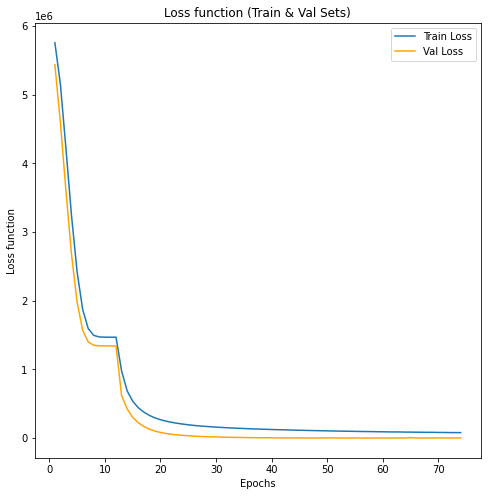

```python
plt.figure(figsize=(8,8))
loss_function = regressor_history.history['loss']
val_loss_function = regressor_history.history['val_loss']
epochs = range(1,len(loss_function)+1)

plt.title('Loss function (Train & Val Sets)')
plt.plot(epochs,loss_function,label='Train Loss')
plt.plot(epochs,val_loss_function,color='orange',label='Val Loss')
plt.xlabel('Epochs')
plt.ylabel('Loss function')
plt.legend()
```

```python
probs = regressor_2.predict(X_test)
truth = y_test
```

```python
mse = round(mean_squared_error(probs, truth), 3)
mae = round(mean_absolute_error(probs, truth), 3)
r2 = round(r2_score(probs, truth), 5)
df_metrics_regress.loc[len(df_metrics_regress.index)] = ['second_model', mse, mae, r2]
```

```python
df_metrics_regress
```

|  | model | mse | mae | r2 |
| --- | --- | --- | --- | --- |
| 0 | base_model | 6439.512 | 51.051 | 0.99453 |
| 1 | second_model | 1658.268 | 28.584 | 0.99859 |

#### Third Model

Увеличим количество нейронов на каждом слое, кроме двух последних:

1. 64 нейрона, функция активации - ReLU
2. 64 нейрона, функция активации - Sigmoid
3. 32 нейрона, функция активации - SeLU
4. 32 нейронов, функция активации - Sigmoid
5. 16 нейронов, функция активации - ReLU
6. 1 нейрон

```python
regressor_3 = Sequential(
    [
        layers.Dense(64, activation = 'relu', input_dim = X_train.shape[1]),
        layers.Dense(64, activation = 'sigmoid'),
        layers.Dense(32, activation = 'selu'),
        layers.Dense(32, activation = 'sigmoid'),
        layers.Dense(16, activation = 'relu'),
        layers.Dense(1)
    ]
)
regressor_3.summary()
```

```
Model: "sequential_7"
_________________________________________________________________
 Layer (type)                Output Shape              Param #
=================================================================
 dense_22 (Dense)            (None, 64)                7232

 dense_23 (Dense)            (None, 64)                4160

 dense_24 (Dense)            (None, 32)                2080

 dense_25 (Dense)            (None, 32)                1056

 dense_26 (Dense)            (None, 16)                528

 dense_27 (Dense)            (None, 1)                 17

=================================================================
Total params: 15073 (58.88 KB)
Trainable params: 15073 (58.88 KB)
Non-trainable params: 0 (0.00 Byte)
_________________________________________________________________
```

```python
regressor_3.compile(loss = 'mean_squared_error', optimizer = 'adam')
```

```python
early_stop = EarlyStopping(monitor = 'val_loss', patience = 10, mode = 'min', verbose = 1)
checkpoint = ModelCheckpoint('household_3-{epoch:02d}-{val_loss:.3f}.hdf5',
                             monitor = 'val_loss', verbose = 1, mode = 'min',
                             save_best_only = True)
callbacks_list = [early_stop,checkpoint]
```

Увеличим число объектов в одном батче в 10 раз и уменьшим количество эпох в 1,25 раз:

```python
regressor_history = regressor_3.fit(X_train, y_train, batch_size = 100, validation_data = (X_valid, y_valid),
                                        callbacks = callbacks_list, epochs = 160)
```

```
Epoch 1: val_loss improved from inf to 1200593.50000, saving model to household_3-01-1200593.500.hdf5
Epoch 2: val_loss improved from 1200593.50000 to 874414.87500, saving model to household_3-02-874414.875.hdf5
Epoch 3: val_loss improved from 874414.87500 to 801919.31250, saving model to household_3-03-801919.312.hdf5
Epoch 4: val_loss improved from 801919.31250 to 744184.93750, saving model to household_3-04-744184.938.hdf5
Epoch 5: val_loss improved from 744184.93750 to 696146.00000, saving model to household_3-05-696146.000.hdf5
Epoch 6: val_loss improved from 696146.00000 to 656418.00000, saving model to household_3-06-656418.000.hdf5
Epoch 7: val_loss improved from 656418.00000 to 615229.25000, saving model to household_3-07-615229.250.hdf5
Epoch 8: val_loss improved from 615229.25000 to 581072.31250, saving model to household_3-08-581072.312.hdf5
Epoch 9: val_loss improved from 581072.31250 to 549156.87500, saving model to household_3-09-549156.875.hdf5
Epoch 10: val_loss improved from 549156.87500 to 521164.56250, saving model to household_3-10-521164.562.hdf5
Epoch 11: val_loss improved from 521164.56250 to 493791.53125, saving model to household_3-11-493791.531.hdf5
Epoch 12: val_loss improved from 493791.53125 to 468453.50000, saving model to household_3-12-468453.500.hdf5
Epoch 13: val_loss improved from 468453.50000 to 444846.90625, saving model to household_3-13-444846.906.hdf5
Epoch 14: val_loss improved from 444846.90625 to 422923.12500, saving model to household_3-14-422923.125.hdf5
Epoch 15: val_loss improved from 422923.12500 to 402136.65625, saving model to household_3-15-402136.656.hdf5
Epoch 16: val_loss improved from 402136.65625 to 382905.15625, saving model to household_3-16-382905.156.hdf5
Epoch 17: val_loss improved from 382905.15625 to 364512.12500, saving model to household_3-17-364512.125.hdf5
Epoch 18: val_loss improved from 364512.12500 to 346870.46875, saving model to household_3-18-346870.469.hdf5
Epoch 19: val_loss improved from 346870.46875 to 331003.06250, saving model to household_3-19-331003.062.hdf5
Epoch 20: val_loss improved from 331003.06250 to 315526.25000, saving model to household_3-20-315526.250.hdf5
Epoch 21: val_loss improved from 315526.25000 to 300811.93750, saving model to household_3-21-300811.938.hdf5
Epoch 22: val_loss improved from 300811.93750 to 287207.90625, saving model to household_3-22-287207.906.hdf5
Epoch 23: val_loss improved from 287207.90625 to 273986.71875, saving model to household_3-23-273986.719.hdf5
Epoch 24: val_loss improved from 273986.71875 to 261652.76562, saving model to household_3-24-261652.766.hdf5
Epoch 25: val_loss improved from 261652.76562 to 250090.84375, saving model to household_3-25-250090.844.hdf5
Epoch 26: val_loss improved from 250090.84375 to 238854.35938, saving model to household_3-26-238854.359.hdf5
Epoch 27: val_loss improved from 238854.35938 to 228586.70312, saving model to household_3-27-228586.703.hdf5
Epoch 28: val_loss improved from 228586.70312 to 218392.87500, saving model to household_3-28-218392.875.hdf5
Epoch 29: val_loss improved from 218392.87500 to 208673.23438, saving model to household_3-29-208673.234.hdf5
Epoch 30: val_loss improved from 208673.23438 to 200004.82812, saving model to household_3-30-200004.828.hdf5
Epoch 31: val_loss improved from 200004.82812 to 191836.37500, saving model to household_3-31-191836.375.hdf5
Epoch 32: val_loss improved from 191836.37500 to 182928.89062, saving model to household_3-32-182928.891.hdf5
Epoch 33: val_loss improved from 182928.89062 to 175069.42188, saving model to household_3-33-175069.422.hdf5
Epoch 34: val_loss improved from 175069.42188 to 167724.62500, saving model to household_3-34-167724.625.hdf5
Epoch 35: val_loss improved from 167724.62500 to 160450.31250, saving model to household_3-35-160450.312.hdf5
Epoch 36: val_loss improved from 160450.31250 to 153786.43750, saving model to household_3-36-153786.438.hdf5
Epoch 37: val_loss improved from 153786.43750 to 147159.62500, saving model to household_3-37-147159.625.hdf5
Epoch 38: val_loss improved from 147159.62500 to 141194.03125, saving model to household_3-38-141194.031.hdf5
Epoch 39: val_loss improved from 141194.03125 to 135041.50000, saving model to household_3-39-135041.500.hdf5
Epoch 40: val_loss improved from 135041.50000 to 129282.23438, saving model to household_3-40-129282.234.hdf5
```

[output cut: 105 more lines]

```
Epoch 146: val_loss improved from 1188.24084 to 1060.97351, saving model to household_3-146-1060.974.hdf5
Epoch 147: val_loss improved from 1060.97351 to 1033.36841, saving model to household_3-147-1033.368.hdf5
Epoch 148: val_loss did not improve from 1033.36841
Epoch 149: val_loss did not improve from 1033.36841
Epoch 150: val_loss did not improve from 1033.36841
Epoch 151: val_loss did not improve from 1033.36841
Epoch 152: val_loss improved from 1033.36841 to 779.99072, saving model to household_3-152-779.991.hdf5
Epoch 153: val_loss improved from 779.99072 to 743.01135, saving model to household_3-153-743.011.hdf5
Epoch 154: val_loss improved from 743.01135 to 674.17694, saving model to household_3-154-674.177.hdf5
Epoch 155: val_loss improved from 674.17694 to 600.09119, saving model to household_3-155-600.091.hdf5
Epoch 156: val_loss did not improve from 600.09119
Epoch 157: val_loss did not improve from 600.09119
Epoch 158: val_loss did not improve from 600.09119
Epoch 159: val_loss did not improve from 600.09119
Epoch 160: val_loss improved from 600.09119 to 415.97696, saving model to household_3-160-415.977.hdf5
```

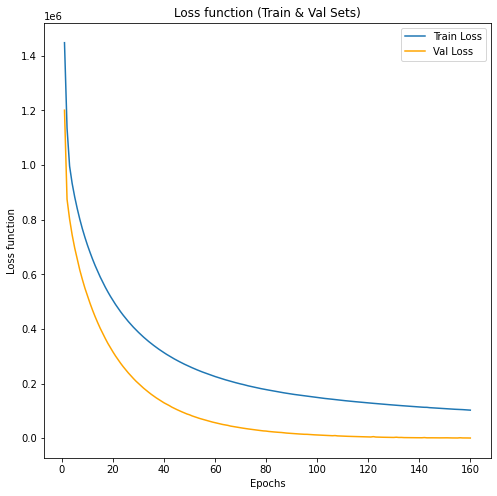

```python
plt.figure(figsize=(8,8))
loss_function = regressor_history.history['loss']
val_loss_function = regressor_history.history['val_loss']
epochs = range(1,len(loss_function)+1)

plt.title('Loss function (Train & Val Sets)')
plt.plot(epochs,loss_function,label='Train Loss')
plt.plot(epochs,val_loss_function,color='orange',label='Val Loss')
plt.xlabel('Epochs')
plt.ylabel('Loss function')
plt.legend()
```

```python
probs = regressor_3.predict(X_test)
truth = y_test
```

```python
mse = round(mean_squared_error(probs, truth), 3)
mae = round(mean_absolute_error(probs, truth), 3)
r2 = round(r2_score(probs, truth), 5)
df_metrics_regress.loc[len(df_metrics_regress.index)] = ['third_model', mse, mae, r2]
```

```python
df_metrics_regress
```

|  | model | mse | mae | r2 |
| --- | --- | --- | --- | --- |
| 0 | base_model | 6439.512 | 51.051 | 0.99453 |
| 1 | second_model | 1658.268 | 28.584 | 0.99859 |
| 2 | third_model | 1169.393 | 6.070 | 0.99900 |

#### Fourth Model

Добавим Dropout(0.1) после нескольких первых слоёв. В первом слое увеличим количество нейронов до 128:

```python
regressor_4 = Sequential(
    [
        layers.Dense(128, activation = 'relu', input_dim = X_train.shape[1]),
        layers.Dropout(0.1),
        layers.Dense(64, activation = 'sigmoid'),
        layers.Dropout(0.1),
        layers.Dense(32, activation = 'selu'),
        layers.Dense(32, activation = 'sigmoid'),
        layers.Dense(16, activation = 'relu'),
        layers.Dense(1)
    ]
)
regressor_4.summary()
```

```
Model: "sequential_13"
_________________________________________________________________
 Layer (type)                Output Shape              Param #
=================================================================
 dense_58 (Dense)            (None, 128)               14464

 dropout_12 (Dropout)        (None, 128)               0

 dense_59 (Dense)            (None, 64)                8256

 dropout_13 (Dropout)        (None, 64)                0

 dense_60 (Dense)            (None, 32)                2080

 dense_61 (Dense)            (None, 32)                1056

 dense_62 (Dense)            (None, 16)                528

 dense_63 (Dense)            (None, 1)                 17

=================================================================
Total params: 26401 (103.13 KB)
Trainable params: 26401 (103.13 KB)
Non-trainable params: 0 (0.00 Byte)
_________________________________________________________________
```

```python
regressor_4.compile(loss = 'mean_squared_error', optimizer = 'adam')
```

```python
early_stop = EarlyStopping(monitor = 'val_loss', patience = 10, mode = 'min', verbose = 1)
checkpoint = ModelCheckpoint('household_4-{epoch:02d}-{val_loss:.3f}.hdf5',
                             monitor = 'val_loss', verbose = 1, mode = 'min',
                             save_best_only = True)
callbacks_list = [early_stop,checkpoint]
```

```python
regressor_history = regressor_4.fit(X_train, y_train, batch_size = 100, validation_data = (X_valid, y_valid),
                                        callbacks = callbacks_list, epochs = 200)
```

```
Epoch 1: val_loss improved from inf to 5742278.50000, saving model to household_4-01-5742278.500.hdf5
Epoch 2: val_loss improved from 5742278.50000 to 5704124.00000, saving model to household_4-02-5704124.000.hdf5
Epoch 3: val_loss improved from 5704124.00000 to 5648713.50000, saving model to household_4-03-5648713.500.hdf5
Epoch 4: val_loss improved from 5648713.50000 to 5577069.50000, saving model to household_4-04-5577069.500.hdf5
Epoch 5: val_loss improved from 5577069.50000 to 5489376.00000, saving model to household_4-05-5489376.000.hdf5
Epoch 6: val_loss improved from 5489376.00000 to 5386085.00000, saving model to household_4-06-5386085.000.hdf5
Epoch 7: val_loss improved from 5386085.00000 to 5263932.00000, saving model to household_4-07-5263932.000.hdf5
Epoch 8: val_loss improved from 5263932.00000 to 5127668.50000, saving model to household_4-08-5127668.500.hdf5
Epoch 9: val_loss improved from 5127668.50000 to 4980515.50000, saving model to household_4-09-4980515.500.hdf5
Epoch 10: val_loss improved from 4980515.50000 to 4823649.50000, saving model to household_4-10-4823649.500.hdf5
Epoch 11: val_loss improved from 4823649.50000 to 4658652.00000, saving model to household_4-11-4658652.000.hdf5
Epoch 12: val_loss improved from 4658652.00000 to 4486653.50000, saving model to household_4-12-4486653.500.hdf5
Epoch 13: val_loss improved from 4486653.50000 to 4309578.00000, saving model to household_4-13-4309578.000.hdf5
Epoch 14: val_loss improved from 4309578.00000 to 4130054.00000, saving model to household_4-14-4130054.000.hdf5
Epoch 15: val_loss improved from 4130054.00000 to 3947504.00000, saving model to household_4-15-3947504.000.hdf5
Epoch 16: val_loss improved from 3947504.00000 to 3754895.50000, saving model to household_4-16-3754895.500.hdf5
Epoch 17: val_loss improved from 3754895.50000 to 3544063.25000, saving model to household_4-17-3544063.250.hdf5
Epoch 18: val_loss improved from 3544063.25000 to 3332451.50000, saving model to household_4-18-3332451.500.hdf5
Epoch 19: val_loss improved from 3332451.50000 to 3129538.75000, saving model to household_4-19-3129538.750.hdf5
Epoch 20: val_loss improved from 3129538.75000 to 2930684.50000, saving model to household_4-20-2930684.500.hdf5
Epoch 21: val_loss improved from 2930684.50000 to 2733526.00000, saving model to household_4-21-2733526.000.hdf5
Epoch 22: val_loss improved from 2733526.00000 to 2553738.25000, saving model to household_4-22-2553738.250.hdf5
Epoch 23: val_loss improved from 2553738.25000 to 2387448.00000, saving model to household_4-23-2387448.000.hdf5
Epoch 24: val_loss improved from 2387448.00000 to 2236775.00000, saving model to household_4-24-2236775.000.hdf5
Epoch 25: val_loss improved from 2236775.00000 to 2100469.25000, saving model to household_4-25-2100469.250.hdf5
Epoch 26: val_loss improved from 2100469.25000 to 1965976.75000, saving model to household_4-26-1965976.750.hdf5
Epoch 27: val_loss improved from 1965976.75000 to 1853825.00000, saving model to household_4-27-1853825.000.hdf5
Epoch 28: val_loss improved from 1853825.00000 to 1756882.50000, saving model to household_4-28-1756882.500.hdf5
Epoch 29: val_loss improved from 1756882.50000 to 1674649.12500, saving model to household_4-29-1674649.125.hdf5
Epoch 30: val_loss improved from 1674649.12500 to 1604816.87500, saving model to household_4-30-1604816.875.hdf5
Epoch 31: val_loss improved from 1604816.87500 to 1546217.75000, saving model to household_4-31-1546217.750.hdf5
Epoch 32: val_loss improved from 1546217.75000 to 1499637.12500, saving model to household_4-32-1499637.125.hdf5
Epoch 33: val_loss improved from 1499637.12500 to 1460814.37500, saving model to household_4-33-1460814.375.hdf5
Epoch 34: val_loss improved from 1460814.37500 to 1431107.50000, saving model to household_4-34-1431107.500.hdf5
Epoch 35: val_loss improved from 1431107.50000 to 1406857.75000, saving model to household_4-35-1406857.750.hdf5
Epoch 36: val_loss improved from 1406857.75000 to 1389024.87500, saving model to household_4-36-1389024.875.hdf5
Epoch 37: val_loss improved from 1389024.87500 to 1374939.37500, saving model to household_4-37-1374939.375.hdf5
Epoch 38: val_loss improved from 1374939.37500 to 1364527.00000, saving model to household_4-38-1364527.000.hdf5
Epoch 39: val_loss improved from 1364527.00000 to 1357665.50000, saving model to household_4-39-1357665.500.hdf5
Epoch 40: val_loss improved from 1357665.50000 to 1352238.37500, saving model to household_4-40-1352238.375.hdf5
```

[output cut: 130 more lines]

```
Epoch 171: val_loss did not improve from 1525.28589
Epoch 172: val_loss did not improve from 1525.28589
Epoch 173: val_loss did not improve from 1525.28589
Epoch 174: val_loss improved from 1525.28589 to 1333.98450, saving model to household_4-174-1333.984.hdf5
Epoch 175: val_loss did not improve from 1333.98450
Epoch 176: val_loss did not improve from 1333.98450
Epoch 177: val_loss did not improve from 1333.98450
Epoch 178: val_loss did not improve from 1333.98450
Epoch 179: val_loss did not improve from 1333.98450
Epoch 180: val_loss did not improve from 1333.98450
Epoch 181: val_loss did not improve from 1333.98450
Epoch 182: val_loss did not improve from 1333.98450
Epoch 183: val_loss did not improve from 1333.98450
Epoch 184: val_loss did not improve from 1333.98450
Epoch 184: early stopping
```

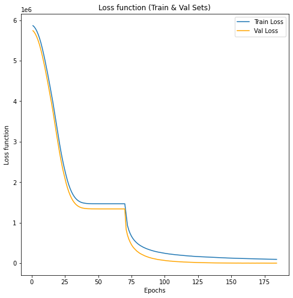

```python
plt.figure(figsize=(8,8))
loss_function = regressor_history.history['loss']
val_loss_function = regressor_history.history['val_loss']
epochs = range(1,len(loss_function)+1)

plt.title('Loss function (Train & Val Sets)')
plt.plot(epochs,loss_function,label='Train Loss')
plt.plot(epochs,val_loss_function,color='orange',label='Val Loss')
plt.xlabel('Epochs')
plt.ylabel('Loss function')
plt.legend()
```

```python
probs = regressor_4.predict(X_test)
truth = y_test
```

```python
mse = round(mean_squared_error(probs, truth), 3)
mae = round(mean_absolute_error(probs, truth), 3)
r2 = round(r2_score(probs, truth), 5)
df_metrics_regress.loc[len(df_metrics_regress.index)] = ['fourth_model', mse, mae, r2]
```

```python
df_metrics_regress
```

|  | model | mse | mae | r2 |
| --- | --- | --- | --- | --- |
| 0 | base_model | 6439.512 | 51.051 | 0.99453 |
| 1 | second_model | 1658.268 | 28.584 | 0.99859 |
| 2 | third_model | 1169.393 | 6.070 | 0.99900 |
| 3 | fourth_model | 2050.751 | 30.916 | 0.99823 |

Анализируя полученные метрики 4-х моделей, можно сделать вывод, что наилучшим регрессором является Third Model.

### Вывод

Набор данных 'DS_2019_public.csv' изначально не содержал пропущенных значений. Столбцы типа object состояли из числовых значений, поэтому мы перевели данные в них в float, а при невозможности такого преобразования удаляли строки с выбросами. В некоторых столбцах были выбросы в виде отрицательных значений. После удаления этих значений появились столбцы с NaN. Cтолбцы с процентом NaN больше 5% мы удалили, а в остальных столбцах удалили строки с пропущенными значениям. Дубликатов нет.

Среди четырёх моделей регрессоров лучше всего сработала Third Model. В ней увеличено число слоёв и нейронов на каждом слое по сравнению с Base Model, но не использовался Dropout(0.1).

Оценка качества регрессоров происходила по следующим метрикам: MSE, MAE и R2. Первые два показателя у Third Model нижу, чем у остальных моделей, а последний - выше.